# swirl

### 2.2. Workspace and Files

> Unix などの file system（ファイルシステム）に慣れている方は別ですが、そうでないと、混乱するかもしれませんので、ていねいに説明します。  
> この課の内容は、実際のプログラムをはじめると、知っていると便利で、理解がしやすく、複雑なプログラムになってくると必須ですが、RStudio で `R` を使う場合には、右下の Pane（窓枠）の Files Tab や、RStudio の menu で代替できる部分も含みます。

```
library(swirl)
```

`swirl` をはじめるときは、ここからはじめます。(Install していない場合は、1.2 `swirl` 起動までを読んでください。また、1: Basic Building Blocks（第1課：基本的構成要素）の続きとして、この課を学ぶときは、不要です。)

```
| Hi! I see that you have some variables saved in your workspace. To keep things running smoothly,
| I recommend you clean up before starting swirl.

| Type ls() to see a list of the variables in your workspace. Then, type rm(list=ls()) to clear
| your workspace.

| Type swirl() when you are ready to begin.
```

*あなたの作業領域に、いくつか、変数を保存してあるようですね。（保存していないかたもいるかもしれません。）支障なく `swirl` で学ぶために、`swirl` を起動する前に、それらを消去しておくことをお勧めします。*

*ls() と入力すると、あなたの作業領域にある、変数のリストが得られます。消去するには、rm(list=ls()) と入力します。*

*swirl() と入力してはじめましょう。*

```
> ls()
[1] "my_div"  "my_sqrt" "x"       "y"       "z"
> rm(list=ls())
> swirl()
```

- これらは、2.1 にある、R Programming 1: Basic Building Blocks（R によるプログラム 第1課：基本的構成要素）のときに使った変数です。それが残っていました。

```
| Welcome to swirl! Please sign in. If you've been here before, use the same name as you did then.
| If you are new, call yourself something unique.

What shall I call you? SL
```

*swirl にようこそ。名前を登録して始めましょう。以前に登録した場合には、同じ名前を使ってください。はじめてのかたは、あなたのことをなんと呼べば良いか、わかりやすい名前を入力してください。*

*何とお呼びしますか？ SL (SL が入力)*

```
| Please choose a course, or type 0 to exit swirl.

1: R Programming
2: Take me to the swirl course repository!

Selection: 1
```

*コースを選択してください。`swirl` を終了するときは、0 を入力してください。*

*1: `R` によるプログラム*  
*2: `swirl` コースのリストへ*.

*選択：1 （SL が入力）*

```
| Please choose a lesson, or type 0 to return to course menu.

 1: Basic Building Blocks      2: Workspace and Files        3: Sequences of Numbers
 4: Vectors                    5: Missing Values             6: Subsetting Vectors
 7: Matrices and Data Frames   8: Logic                      9: Functions
10: lapply and sapply         11: vapply and tapply         12: Looking at Data
13: Simulation                14: Dates and Times           15: Base Graphics


Selection: 2
```

*どの課（クラス）からはじめるか選択してください。0 を入力すると、コースのメニューに戻ります。*

1: 基本的構成要素 2: 作業スペースとファイル 3: 数列  
4: ベクトル 5: 欠損値 6: ベクトルの部分抽出  
7: 行列と、データフレーム 8: 論理 9: 関数  
10: `lapply` と `sapply` 11: `vapply` と `tapply` 12: データの観察  
13: シミュレーション 14: 日付と時間 15: グラフィックの基本

*選択：2 （SL が入力）*

```
| In this lesson, you'll learn how to examine your local workspace in R and begin to explore the
| relationship between your workspace and the file system of your machine.

...
```

*この課では、`R` の作業領域 (workspace) と、あなたが使っているコンピュータの、ファイルシステムの関係について学びます。（… まで読んだら、Enter です。）*

```
| Because different operating systems have different conventions with regards to things like file
| paths, the outputs of these commands may vary across machines.

...
```

*一般的には、異なるオペレーティングシステム（Windows, MacOS, Linux）では、ファイルのパス（そのファイルにたどり着く「道 (path)」の情報）や、それに関する出力形式が異なります。（… まで読んだら、Enter です。以下省略。）*

Windows や、Mac では、GUI (Graphical User Interface) を使うことが多く、フォルダ (Folder) という言い方をしますが、File System としては、ディレクトリ (Directory)と呼びます。Unix では、ディレクトリも File として扱いますが、それは、今は、必要ないでしょう。ディレクトリとあったら、Windows や、Mac の フォルダ (Folder) だと思ってください。その中の書類（画像ファイルなども含めて）が File です。

```
| However it's important to note that R provides a common API (a common set of commands) for
| interacting with files, that way your code will work across different kinds of computers.

...
```

*しかし、R では、オペレーティングシステムに依存しない、共通の API (Application Programming Interface, 共通の命令群) を使って操作することができます。*

```
| Let's jump right in so you can get a feel for how these special functions work!

...
```

*これらの関数がどのように作用するのか、ともかく使ってみましょう。*

```
| Determine which directory your R session is using as its current working directory using
| getwd().
```

*現在の作業ディレクトリ（Current Working Directory）名を、`getwd()` で表示してください。*

’>’ は `R` Prompt で入力する必要はありません。出力は、隠してあります。

```
> getwd()
[1] *********

| All that practice is paying off!
```

*練習のおかげですね。* `|=========== | 13% | List all the objects in your local workspace using ls().` *ls() を使って、あなたの作業領域にある、Objects（もの、保存した変数など）を表示してください。*

```
> ls()
character(0)

| That's correct!
```

*正しいです。*

```
| Some R commands are the same as their equivalents commands on Linux or on a Mac. Both Linux and
| Mac operating systems are based on an operating system called Unix. It's always a good idea to
| learn more about Unix!

...
```

*Rの命令のいくつかは、Linux や、Mac の同様の命令と同じです。Mac は、Unix という オペレーティングシステムの上にできています。Unix について学ぶと良いですよ。*

```
| Assign 9 to x using x <- 9.
```

*9 を 変数 x に割り当て（置い）てください。*

```
> x <- 9

| Perseverance, that's the answer.
```

*頑張りましたね。それが答えです。*

```
| Now take a look at objects that are in your workspace using ls().
```

*あなたの作業領域 (workspace) の Objects がどうなったか表示してください。*

```
> ls()
[1] "x"

| You're the best!
```

*最高です。*

```
| List all the files in your working directory using list.files() or dir().
```

*list.files() または、dir() を使って、作業ディレクトリにある、files を表示してください。*

```
> list.files()
[1] *********

| You are amazing!
```

*驚きです。*

```
| As we go through this lesson, you should be examining the help page for each new function. Check
| out the help page for list.files with the command ?list.files.
```

*この課の学びを進めるとき、新しい関数が登場したら、Help ページをチェックすることをお勧めします。まず、?list.files として、list.files について調べてください。*

RStudio を使っているときは、右下の Pane の Help タブに、説明が表示されます。

```
> ?list.files

| Keep working like that and you'll get there!
```

*その調子で良いですよ。*

```
| One of the most helpful parts of any R help file is the See Also section. Read that section for
| list.files. Some of these functions may be used in later portions of this lesson.

...
```

*R の Help の See Also（参照）の部分はとても有用ですから、list.files の対応する部分を読んでください。See Also にある、関数は、あとで、使うかもしれません。*

```
| Using the args() function on a function name is also a handy way to see what arguments a
| function can take.
...
```

*args() はその関数の引数（その関数を使うときに必要な変数）を表示します。*

```
| Use the args() function to determine the arguments to list.files().
```

*args() を使って、list.files() の引数を表示してください。*

```
> args(list.files)
function (path = ".", pattern = NULL, all.files = FALSE, full.names = FALSE,
    recursive = FALSE, ignore.case = FALSE, include.dirs = FALSE,
    no.. = FALSE)
NULL

| Keep working like that and you'll get there!
```

*その調子で良いですよ。*

`args()` を Help （RStudio なら右下の Pane の Help Tab）で、args と入れて調べてみることをお勧めします。

```
| Assign the value of the current working directory to a variable called "old.dir".
```

*現在の作業ディレクトリを old.dir という変数に割り当ててください。*

```
> old.dir <- getwd()

| Great job!
```

*やりましたね。*

```
| We will use old.dir at the end of this lesson to move back to the place that we started. A lot
| of query functions like getwd() have the useful property that they return the answer to the
| question as a result of the function.

...
```

*old.dir はこの課の最後に使います。getwd() のような、質問に答えてくれる関数は、その質問の答えを返してくれるので、便利です。*

```
| Use dir.create() to create a directory in the current working directory called "testdir".
```

*現在の作業ディレクトリに、“testdir” という名前の新しい、Directory（ディレクトリ）を dir.create() を使って、作成してください。*

少しずつ用語を英語に切り替えていきます。英語に慣れるためです。

```
> dir.create("testdir")

| Great job!
```

*やりましたね。*

```
| We will do all our work in this new directory and then delete it after we are done. This is the
| R analog to "Take only pictures, leave only footprints."

...
```

*これから、この新しい Directory で、すべての作業をし、すべて終了してから、それを、消去します。これは、R を使った、いわゆる、「とるものは写真だけ、残すのは足跡のみにしてください」（観光地での標語）の実践です。*

```
| Set your working directory to "testdir" with the setwd() command.
```

*“testdir” を、setwd() を使って、作業ディレクトリに指定してください。*

```
> setwd("testdir")

| Excellent work!
```

*素晴らしい。*

```
| In general, you will want your working directory to be someplace sensible, perhaps created for
| the specific project that you are working on. In fact, organizing your work in R packages using
| RStudio is an excellent option. Check out RStudio at http://www.rstudio.com/

...
```

*一般的には、作業ディレクトリは、あるプロジェクトを実行するための実用的な Directory（ディレクトリ）です。実際、RStudio では、まず、プロジェクトの Directory（ディレクトリ）を作成し、R Package を使って、プロジェクトを進めていきますが、とてもすぐれた方法です。RStudio については、http://www.rstudio.com/ で調べてください。*

```
| Create a file in your working directory called "mytest.R" using the file.create() function.
```

*file.create() 関数を使って、あなたの作業ディレクトリに、“mytest.R” という名前のファイルを作成してください。*

```
> file.create("mytest.R")
[1] TRUE

| You're the best!
```

*最高です。*

```
| This should be the only file in this newly created directory. Let's check this by listing all
| the files in the current directory.
```

*新しく作成した Directory（ディレクトリ）にあるのは、このファイルだけのはずです。現在の Directory（ディレクトリ）のファイルをすべて表示してください。*

```
> list.files()
[1] "mytest.R"

| You got it!
```

*その通りです。*

```
| Check to see if "mytest.R" exists in the working directory using the file.exists() function.
```

*file.exists() 関数を利用して、“mytest.R” という名前のファイルが、作業ディレクトリに存在するかどうか調べてください。*

```
> file.exists("mytest.R")
[1] TRUE

| That's the answer I was looking for.
```

*そうです。それが、期待したものです。*

```
| These sorts of functions are excessive for interactive use. But, if you are running a program
| that loops through a series of files and does some processing on each one, you will want to
| check to see that each exists before you try to process it.

...
```

*これらの関数は、対話型で利用するときには、必要ないかもしれませんが、プログラムを動かし、たくさんのファイルについて、何らかの作業をする場合など、そのファイルが存在するかどうか確認することは、必要になってきます。*

```
| Access information about the file "mytest.R" by using file.info().
```

*file.info() を利用して、“mytest.R” という名前のファイルの情報を得てみましょう。*

出力の一部を消去しました。

```
> file.info("mytest.R")
         size isdir mode               mtime               ctime               atime uid gid
mytest.R    0 FALSE  644 2020-03-31 17:51:09 2020-03-31 17:51:09 2020-03-31 17:51:10 501  20
           uname grname
mytest.R ******  *******

| Your dedication is inspiring!
```

*感動ものです。*

```
| You can use the $ operator --- e.g., file.info("mytest.R")$mode --- to grab specific items.

...
```

*$ 作用素を使うこともできます。たとえば、file.info(“mytest.R”)$mode とすると、情報の一部を取り出すことができます。*

```
| Change the name of the file "mytest.R" to "mytest2.R" by using file.rename().

> file.rename("mytest.R", "mytest2.R")
[1] TRUE
```

*file.rename() 関数を使って、“mytest.R” という名前のファイル名を、“mytest2.R” に変えてみてください。*

```
| That's the answer I was looking for.
```

*そうです。それが、期待したものです。*

```
| Your operating system will provide simpler tools for these sorts of tasks, but having the
| ability to manipulate files programatically is useful. You might now try to delete mytest.R
| using file.remove('mytest.R'), but that won't work since mytest.R no longer exists. You have
| already renamed it.

...
```

*あなたが使っているオペレーティングシステムでは、もっと簡単に同様のことができるかもしれません。しかし、File についてのこのような作業をプログラムとしてできることは、有用です。mytest.R というファイルを file.remove(‘mytest.R’) を使って、削除しようとします。しかし、すでに、そのファイルは、名前を変えてあり、存在しませんから、その作業はできません。*

```
| Make a copy of "mytest2.R" called "mytest3.R" using file.copy().
```

*“mytest2.R” の複製（copy）をして、“mytest3.R” という名前のファイルを、file.copy() 関数で作成してください。*

```
> file.copy("mytest2.R", "mytest3.R")
[1] TRUE

| You are doing so well!
```

*とてもうまくいっていますよ。*

```
| You now have two files in the current directory. That may not seem very interesting. But what if
| you were working with dozens, or millions, of individual files? In that case, being able to
| programatically act on many files would be absolutely necessary. Don't forget that you can,
| temporarily, leave the lesson by typing play() and then return by typing nxt().

...
```

*現在のディレクトリに、二つのファイルがあります。それほど面白いと思わないかもしれませんが、たくさんの、そして、無数のファイルを扱うときには、プログラムを使うことが必要です。一度、play() と入力することで、この課を離れて、また、nxt() と入力して、戻ってみてください。*

この間に、復習をしたり、いくつかの関数の Help を見てみることもお勧めです。

```
| Provide the relative path to the file "mytest3.R" by using file.path().
```

*“mytest3.R” の相対パス（現在のディレクトリからのパス）を、file.path() を使って、求めてください。*

パスは、そのディレクトリやファイルにたどり着く「道 (path)」の情報のことでした。どこからはじめるかにりょい、相対パス (relative path)、絶対パス (absolute path or full path) という用語が使われます。絶対パスは、そのコンピュータの一番ものと root という場所からのパスのことです。作業ディレクトリの概念をはっきりしておくことで、そこからの、相対パスで作業ができ、他のコンピュータで作業をするときにも、同じプログラムが使えるようになります。

```
> file.path("mytest3.R")
[1] "mytest3.R"

| You nailed it! Good job!
```

*見事です。* `|======================================================================= | 79% | You can use file.path to construct file and directory paths that are independent of the | operating system your R code is running on. Pass 'folder1' and 'folder2' as arguments to | file.path to make a platform-independent pathname.` *file.path 関数を使って、ファイルや、ディレクトリのパスを、R を走らせている、オペレーティングシステムに依存せずに、作成することができます。file.path の引数（arguments）として、‘folder1’ と ‘folder2’ をわたして、file.path で、パスの名前を作成してください。*

```
> file.path('folder1', 'folder2')
[1] "folder1/folder2"

| Excellent work!
```

*素晴らしい。*

```
| Take a look at the documentation for dir.create by entering ?dir.create . Notice the 'recursive'
| argument. In order to create nested directories, 'recursive' must be set to TRUE.
```

*dir.create について、?dir.create として、説明を見てください。‘recursive’（再帰的）という引数があるのがわかりますか。ディレクトリの中にディレクトリが入った、入れ子にするときには、‘recursive’ を TRUE にします。*

```
> ?dir.create

| Your dedication is inspiring!
```

*感動ものです。*

```
| Create a directory in the current working directory called "testdir2" and a subdirectory for it
| called "testdir3", all in one command by using dir.create() and file.path().
```

*現在のディレクトリの中に、“testdir2” という名のディレクトリを作成し、その中に、“testdir3” というディレクトリを作成してください。dir.create() と file.path() を組合せて、一つの命令で実行することができます。*

```
> dir.create(file.path("testdir2","testdir3"), recursive = TRUE)

| You're the best!
```

*最高です。*

```
| Go back to your original working directory using setwd(). (Recall that we created the variable
| old.dir with the full path for the orginal working directory at the start of these questions.)

> setwd(old.dir)
```

*最初の、作業ディレクトリに setwd() を使って戻りましょう。（old.dir に完全パスを保存しておきました。）*

```
| Keep up the great work!
```

*その調子です。*

```
| It is often helpful to save the settings that you had before you began an analysis and then go
| back to them at the end. This trick is often used within functions; you save, say, the par()
| settings that you started with, mess around a bunch, and then set them back to the original
| values at the end. This isn't the same as what we have done here, but it seems similar enough to
| mention.

...
```

*作業を始める前にその設定を保存しておいて、最後に戻ってくることは有効です。このことは、関数の中で、たとえば、par() と設定して、はじめ、混乱するようなことをしても、最初に戻ってくるようにできます。これは、ここでしたこととは異なりますが、同様なことなので、ここに書きました。*

```
| After you finish this lesson delete the 'testdir' directory that you just left (and everything
| in it)

...
```

*この課が終わったら、いま、出てきた’testdir’ を削除して、その中にあるものも含めて消去してください。*

```
| Take nothing but results. Leave nothing but assumptions. That sounds like 'Take nothing but
| pictures. Leave nothing but footprints.' But it makes no sense! Surely our readers can come up
| with a better motto . . .

...
```

*結果だけを得れば良い。仮定だけわかればよい。これは、「とるものは写真だけ、残すのは足跡のみにしてください」（観光地での標語）と聞こえますね。しかし、そうでしょうか。みなさんには、もっとよい、標語がありますよね。*

```
  |=======================================================================================  |  97%
| In this lesson, you learned how to examine your R workspace and work with the file system of
| your machine from within R. Thanks for playing!

...
```

*この課では、R の作業空間と、ファイルシステムを、R でどのように操作するかを学びました。*

```
  |=========================================================================================| 100%
| Would you like to receive credit for completing this course on Coursera.org?

1: No
2: Yes

Selection: 1
```

*Coursera.org の終了認定が欲しいですか。*

**注：Beginner 用の R Programming の各 Lesson の最後に、‘Would you like to receive credit for completing this course on Coursera.org?’ とメッセージが表示されますが、1: No を選択してください。（[`swirl` Course Repository](https://github.com/swirldev/swirl_courses#swirl-courses) 参照）**

```
| Excellent work!
```

*素晴らしい。*

```
| You've reached the end of this lesson! Returning to the main menu...

| Please choose a course, or type 0 to exit swirl.

1: R Programming
2: Take me to the swirl course repository!

Selection: 0
```

*２課の最後までたどり着きました。メニューに戻るには、*

*コースを選択してください。`swirl` を終了するときは、0 を入力してください。*

*1: `R` によるプログラム*  
*2: ｀swirl` コースのリストへ*.

*選択：0 （SL が入力）*

```
| Leaving swirl now. Type swirl() to resume.
```

*swirl を終了します。再開するときは、swirl() と入力してください。*

```
>
```

### 2.3. Sequences of Numbers

> 数列 (Sequences of Numbers) を作る方法を練習します。基本的ですから、よくご存じの方以外は、スキップしないでください。  
> `swirl()` ではじめるところから、解説します。最初に、swirl を Install したり、`library(swirl)` を実行する部分は、省略します。よくわからない方は、2.2 または、2.1 の最初の部分を復習してください。

```
> swirl()
```

次のステップも同じですから、和訳や解説は省略します。

```
| Welcome to swirl! Please sign in. If you've been here before, use the same name as you did then.
| If you are new, call yourself something unique.

What shall I call you? SL

| Please choose a course, or type 0 to exit swirl.

1: R Programming
2: Take me to the swirl course repository!

Selection: 1

| Please choose a lesson, or type 0 to return to course menu.

 1: Basic Building Blocks      2: Workspace and Files        3: Sequences of Numbers
 4: Vectors                    5: Missing Values             6: Subsetting Vectors
 7: Matrices and Data Frames   8: Logic                      9: Functions
10: lapply and sapply         11: vapply and tapply         12: Looking at Data
13: Simulation                14: Dates and Times           15: Base Graphics


Selection: 3
```

3: Sequences of Numbers（第３課 数列）を選択しました。

```
| In this lesson, you'll learn how to create sequences of numbers in R.

...
```

*この課では、R で数列を作る方法を学びます。*

```
| The simplest way to create a sequence of numbers in R is by using the `:` operator. Type 1:20 to
| see how it works.
```

*R で一番簡単に数列を作るには、`:` 作用素を使います。1:20 と入力し、どんな具合か見てみましょう。*

```
> 1:20
 [1]  1  2  3  4  5  6  7  8  9 10 11 12 13 14 15 16 17 18 19 20

| That's the answer I was looking for.
```

*そうです。それが、期待したものです。*

```
| That gave us every integer between (and including) 1 and 20. We could also use it to create a
| sequence of real numbers. For example, try pi:10.
```

*1からはじまり20までの整数（integer）の列となります。実数からも数列を作れます。pi:10 を試してみてください。*

```
> pi:10
[1] 3.141593 4.141593 5.141593 6.141593 7.141593 8.141593 9.141593

| That's correct!
```

*正しいです。*

```
| The result is a vector of real numbers starting with pi (3.142...) and increasing in increments
| of 1. The upper limit of 10 is never reached, since the next number in our sequence would be
| greater than 10.

...
```

*結果として得られるベクトル（数が並んだもの）はまず、pi(3.142…) から始まり、1 ずつ加えていき、10を超さない範囲に収まるようになっています。*

```
| What happens if we do 15:1? Give it a try to find out.
```

*では、15:1 ではどうでしょうか。試してみてください。*

**ちょっと間違ってみました。1ではなく、17と入れてみました。**

```
> 15:17
[1] 15 16 17
```

```
| Give it another try. Or, type info() for more options.

| Type 15:1 and press Enter.
```

*もう一度やってみたください。info() 入力してみるのも一つです。15:1 を入力し、Enter を押します。*

ということで、info() の方をまず試してみました。

```
> info()

| When you are at the R prompt (>):
| -- Typing skip() allows you to skip the current question.
| -- Typing play() lets you experiment with R on your own; swirl will ignore what you do...
| -- UNTIL you type nxt() which will regain swirl's attention.
| -- Typing bye() causes swirl to exit. Your progress will be saved.
| -- Typing main() returns you to swirl's main menu.
| -- Typing info() displays these options again.
```

覚えていますか。最初にこの説明がありました。この日本語を知りたい人は、1.3 を参照してください。

```
> 15:1
 [1] 15 14 13 12 11 10  9  8  7  6  5  4  3  2  1

| Keep working like that and you'll get there!
```

*その調子で良いですよ。*

```
| It counted backwards in increments of 1! It's unlikely we'd want this behavior, but nonetheless
| it's good to know how it could happen.
...
```

*1ずつ逆向きに（数を減らしていく方向に）数列を生成しました。このようなことは、考えないかもしれませんが、何が起こるか知っておいてもよいと思います。*

```
| Remember that if you have questions about a particular R function, you can access its
| documentation with a question mark followed by the function name: ?function_name_here. However,
| in the case of an operator like the colon used above, you must enclose the symbol in backticks
| like this: ?`:`. (NOTE: The backtick (`) key is generally located in the top left corner of a
| keyboard, above the Tab key. If you don't have a backtick key, you can use regular quotes.)

...
```

*R 関数について、質問があるときは、その関数の前に ? をつけて Help を求めるのでした。しかし、この場合のコロン（:）の場合には、baktick (`) で囲む必要があります。通常は、キーボードの左上、TAB キーの上にあります。もし、見つけられないときは、通常の引用符を使ってください。*

ちょっと試してみましたが、他の引用符ではうまくいかないようです。また、RStudio の右下の pane の虫眼鏡の窓に入れるときは、: のままが良いようです。ただ、この backtick は重要なので、ちょっと説明しておきます。上の、説明は、通常 ASCII キーボード、US キーボードと言われるものの配列です、日本では、JIS キーボードを使っている場合が多いと思うので（ASCII にひらがなをつけているものもあります。左上、TAB の上に、backtick があれば、ASCII 型です。）、P の右横、@ の上にあります。ということで、シフトを押して、@ となります。ついでに、引用符（quotation mark）について少し書いておきます。多用するようになったときに、もう一度書きます。すでに、出てきていますが、single quote (’) と、double quote (") があります。R では、基本的に、どちらも同じだと考えてください。

```
| Pull up the documentation for `:` now.
```

*`:` を使って、説明文書を見てみてください。*

? のあとにすぐ `:` を入力すればよいのですが、space を一つ入れてみました。問題ありませんね。どんどん、試してみてください。たいへんなことは起こりません。心配なら、play() として、一旦、swirl を抜けて、練習をし、nxt() で戻ってくれば良いでしょう。

```
> ? `:`

| Excellent work!
```

*素晴らしい。*

```
| Often, we'll desire more control over a sequence we're creating than what the `:` operator gives
| us. The seq() function serves this purpose.

...
```

*`:` よりももっと複雑なことをしたいときがあります。そのときは、seq() を使います。*

```
| The most basic use of seq() does exactly the same thing as the `:` operator. Try seq(1, 20) to
| see this.
```

*最も基本的な使い方として、`:` と同じことをしてみましょう。seq(1,20) を試してください。*

```
> seq(1,20)
 [1]  1  2  3  4  5  6  7  8  9 10 11 12 13 14 15 16 17 18 19 20

| All that practice is paying off!
```

*練習のおかげですね。*

```
| This gives us the same output as 1:20. However, let's say that instead we want a vector of
| numbers ranging from 0 to 10, incremented by 0.5. seq(0, 10, by=0.5) does just that. Try it out.
```

*1:20 と同じ結果を得ました。しかし、たとえば、0 からはじめ 10 までの数列ですが、増加分を、0.5 としてみましょう。seq(0, 10, by=0.5) です。試してみてください。*

```
> seq(0, 10, by=0.5)
 [1]  0.0  0.5  1.0  1.5  2.0  2.5  3.0  3.5  4.0  4.5  5.0  5.5  6.0  6.5  7.0  7.5  8.0  8.5  9.0
[20]  9.5 10.0

| You are amazing!
```

*驚きです。*

```
| Or maybe we don't care what the increment is and we just want a sequence of 30 numbers between 5
| and 10. seq(5, 10, length=30) does the trick. Give it a shot now and store the result in a new
| variable called my_seq.
```

*増加分ではなく、全体で 30個の数から成る列を生成したいとします。そのときは、seq(5, 10, length=30) を使います。やってみましょう。その結果を、my_seq という名前の変数に割り当ててください。*

```
> my_seq <- seq(5, 10, length=30)

| Keep up the great work!
```

*その調子です。*

```
| To confirm that my_seq has length 30, we can use the length() function. Try it now.
```

*たしかに、長さが、30 の数列を生成したことを、length() 関数を用いて、確認してください。*

```
> length(my_seq)
[1] 30

| Great job!
```

*やりましたね。*

```
| Let's pretend we don't know the length of my_seq, but we want to generate a sequence of integers
| from 1 to N, where N represents the length of the my_seq vector. In other words, we want a new
| vector (1, 2, 3, ...) that is the same length as my_seq.

...
```

*いま、my_seq の長さを知らないと仮定して、その長さと同じ、1 からはじめ N までの数列を作ろうとします。ここで、N は、my_seq の長さになります。*

```
| There are several ways we could do this. One possibility is to combine the `:` operator and the
| length() function like this: 1:length(my_seq). Give that a try.
```

*いくつかの方法がありますが、一つの方法は、1:length(my_seq) とすることです。試してみてください。*

```
> 1:length(my_seq)
 [1]  1  2  3  4  5  6  7  8  9 10 11 12 13 14 15 16 17 18 19 20 21 22 23 24 25 26 27 28 29 30

| Your dedication is inspiring!
```

*感動ものです。*

```
| Another option is to use seq(along.with = my_seq). Give that a try.
```

*もう一つの方法は、seq(along.with = my_seq) です。試してみてください。*

```
> seq(along.with = my_seq)
 [1]  1  2  3  4  5  6  7  8  9 10 11 12 13 14 15 16 17 18 19 20 21 22 23 24 25 26 27 28 29 30

| All that hard work is paying off!
```

*努力は報われます。*

```
| However, as is the case with many common tasks, R has a separate built-in function for this
| purpose called seq_along(). Type seq_along(my_seq) to see it in action.
```

*よくある作業については、これとは、別に、そのための関数も R に用意されています。seq_along()*

```
> seq_along(my_seq)
 [1]  1  2  3  4  5  6  7  8  9 10 11 12 13 14 15 16 17 18 19 20 21 22 23 24 25 26 27 28 29 30

| All that hard work is paying off!
```

*努力は報われます。*

```
| There are often several approaches to solving the same problem, particularly in R. Simple
| approaches that involve less typing are generally best. It's also important for your code to be
| readable, so that you and others can figure out what's going on without too much hassle.

...
```

*R では、同じ問題を解決するのにいくつもの方法がある場合があります。一般的に一番良いのは、入力する文字数が少ないことです。それ以外にも、code（プロセスを記号化したもの、プログラム）が他のひとにとっても読みやすく (readable) 理解しやすいということも大切です。*

```
| If R has a built-in function for a particular task, it's likely that function is highly
| optimized for that purpose and is your best option. As you become a more advanced R programmer,
| you'll design your own functions to perform tasks when there are no better options. We'll
| explore writing your own functions in future lessons.

...
```

*Rに付属の関数は、特定の作業のために特化しています。あなたが、上級の R のプログラマーにあんると、目的に合った命令を、自分で作ろうとするでしょう。その方法については、いずれ勉強します。*

```
| One more function related to creating sequences of numbers is rep(), which stands for
| 'replicate'. Let's look at a few uses.

...
```

*もう一つの数列を作成する関数として、rep() があります。これは、‘replicate’（複製）からとられています。いくつか例を見てみましょう。*

```
| If we're interested in creating a vector that contains 40 zeros, we can use rep(0, times = 40).
| Try it out.
```

*40個 0 が並んだ列を作りたいとします。そのときは、rep(0, times = 40) を使います。試してみてください。*

```
> rep(0, times = 40)
 [1] 0 0 0 0 0 0 0 0 0 0 0 0 0 0 0 0 0 0 0 0 0 0 0 0 0 0 0 0 0 0 0 0 0 0 0 0 0 0 0 0

| Nice work!
```

*それで良いですよ。*

```
| If instead we want our vector to contain 10 repetitions of the vector (0, 1, 2), we can do
| rep(c(0, 1, 2), times = 10). Go ahead.
```

*(0,1,2) というベクトルを、10個ならべたものを作成するときは、rep(c(0, 1, 2), times = 10) とします。さあ、やってみましょう。*

```
> rep(c(0, 1, 2), times = 10)
 [1] 0 1 2 0 1 2 0 1 2 0 1 2 0 1 2 0 1 2 0 1 2 0 1 2 0 1 2 0 1 2

| Excellent work!
```

*素晴らしい。*

```
| Finally, let's say that rather than repeating the vector (0, 1, 2) over and over again, we want
| our vector to contain 10 zeros, then 10 ones, then 10 twos. We can do this with the `each`
| argument. Try rep(c(0, 1, 2), each = 10).
```

*最後に (0, 1, 2) を何回も繰り返すのではなく、0 を 10回、1 を 10回、2 を 10回繰り返したいときは、argument（引数）の `eachi` を使います。 rep(c(0, 1, 2), each = 10) を試してみてください。*

```
> rep(c(0, 1, 2), each = 10)
 [1] 0 0 0 0 0 0 0 0 0 0 1 1 1 1 1 1 1 1 1 1 2 2 2 2 2 2 2 2 2 2

| Keep working like that and you'll get there!
```

*その調子で良いですよ。*

```
|=========================================================================================| 100%
| Would you like to receive credit for completing this course on Coursera.org?

1: No
2: Yes

Selection: 1
```

*Coursera.org の終了認定が欲しいですか。*

2 を入力すると、2桁の token（証明のしるし）を入力しなさいと表示されます。Moocs の 一つの、Coursera で使われていたものなのでしょう。

```
| Keep up the great work!

| You've reached the end of this lesson! Returning to the main menu...

| Please choose a course, or type 0 to exit swirl.

1: R Programming
2: Take me to the swirl course repository!

Selection: 0
```

*その調子です。*

*課の最後までたどり着きました。メニューに戻るには、*

*コースを選択してください。`swirl` を終了するときは、0 を入力してください。*

*1: `R` によるプログラム*  
*2: ｀swirl` コースのリストへ*.

*選択：0 （SL が入力）*

```
| Leaving swirl now. Type swirl() to resume.
```

*swirl を終了します。再開するときは、swirl() と入力してください。*

```
>
```

### 2.4. Vectors

> 数ベクトル（numeric vectors）については、2.1 Basic Building Blocks（基本的構成要素）で、すでに、少し学びましたが、文字列や、論理値のベクトルについて学びます。R がどのように、ベクトルを扱うのかは、とても基本的ですので、よくご存じの方以外は、スキップしないでください。  
> swirl() ではじめるところから、解説します。最初に、swirl を Install したり、library(swirl) を実行する部分は、省略します。よくわからない方は、1.2 または、1.1 の最初の部分を復習してください。

```
> swirl()
```

次のステップも同じですから、和訳や解説は省略します。

```
| Welcome to swirl! Please sign in. If you've been here before, use the same name as you did then.
| If you are new, call yourself something unique.

What shall I call you? SL

| Please choose a course, or type 0 to exit swirl.

1: R Programming
2: Take me to the swirl course repository!

Selection: 1

| Please choose a lesson, or type 0 to return to course menu.

 1: Basic Building Blocks      2: Workspace and Files        3: Sequences of Numbers
 4: Vectors                    5: Missing Values             6: Subsetting Vectors
 7: Matrices and Data Frames   8: Logic                      9: Functions
10: lapply and sapply         11: vapply and tapply         12: Looking at Data
13: Simulation                14: Dates and Times           15: Base Graphics


Selection: 4
```

4: Vectors（第４課 ベクトル）を選択しました。

```
| The simplest and most common data structure in R is the vector.

...
```

*R の一番簡単な、データ構造（data structure）は vector（ベクトル）です。*

```
| Vectors come in two different flavors: atomic vectors and lists. An atomic vector contains
| exactly one data type, whereas a list may contain multiple data types. We'll explore atomic
| vectors further before we get to lists.

...
```

*ベクトルには、二種類あります。atomic vectors（原子ベクトル）と lists（リスト）です。atomic vector は、一つの種類（クラス）のデータを含みますが、list の方は、複数の種類（クラス）のデータを含むことが可能です。ここでは、list を学ぶ前に、一種類（クラス）のデータからなる atomic vector について学びます。*

```
| In previous lessons, we dealt entirely with numeric vectors, which are one type of atomic
| vector. Other types of atomic vectors include logical, character, integer, and complex. In this
| lesson, we'll take a closer look at logical and character vectors.

...
```

*以前の課では、数ベクトル (numeric vectors) について学びました。これは、atomic vector の一つです。他の種類の atomic vector には、論理、文字、整数、複素数を含むものがあります。この課では、論理ベクトルと、文字ベクトルについて学びます。*

```
| Logical vectors can contain the values TRUE, FALSE, and NA (for 'not available'). These values
| are generated as the result of logical 'conditions'. Let's experiment with some simple
| conditions.

...
```

*論理ベクトルは、TRUE（真）, FALSE（偽）, NA (‘not available’ 不明) の三種類の値から成ります。これらは、論理的な条件（conditions）によって、生成されます。いくつかの条件について見てみましょう。*

```
| First, create a numeric vector num_vect that contains the values 0.5, 55, -10, and 6.
```

*まず、0.5, 55, -10, 6 からなる数ベクトル、num_vect を作成してください。*

```
> num_vect <- c(0.5, 55, -10, 6)

| All that hard work is paying off!
```

*努力は報われます。*

```
| Now, create a variable called tf that gets the result of num_vect < 1, which is read as
| 'num_vect is less than 1'.
```

*今度は、num_vect < 1 の結果からなる、tf という名前のベクトルを作ってください。「num_vec は、1 より小さい」という条件です。*

```
> tf <- num_vect < 1

| Nice work!
```

*それで良いですよ。*

```
| What do you think tf will look like?

1: a single logical value
2: a vector of 4 logical values
```

*tf はどんな形をしていると思いますか。*

*1: 一つの値*  
*2: 四つの論理値からなるベクトル*

```
Selection: 2

| Great job!
```

*やりましたね。*

```
| Print the contents of tf now.
```

*tf の中身を見てください。*

```
> tf
[1]  TRUE FALSE  TRUE FALSE

| Excellent job!
```

*素晴らしい。*

```
| The statement num_vect < 1 is a condition and tf tells us whether each corresponding element of
| our numeric vector num_vect satisfies this condition.

...
```

*statement num_vect < 1 は、数ベクトル num_vect のそれぞれの、成分が、条件を満たしているかということです。*

```
| The first element of num_vect is 0.5, which is less than 1 and therefore the statement 0.5 < 1
| is TRUE. The second element of num_vect is 55, which is greater than 1, so the statement 55 < 1
| is FALSE. The same logic applies for the third and fourth elements.

...
```

*num_vect の最初は、0.5 で、これは、1 より小さいので、0.5 < 1 は TRUE（真）です。二つ目は、55 で、1 より大きいので、55 < 1 は、FALSE（偽）です。同じ論理が、num_vect の三つ目、四つ目の成分についても適用されます。*

```
| Let's try another. Type num_vect >= 6 without assigning the result to a new variable.
```

*もう一つ試してみましょう。num_vect >= 6 を新しい、変数に割り当てることはしないで、入力してください。*

```
> num_vect >= 6
[1] FALSE  TRUE FALSE  TRUE

| You got it!
```

*その通りです。*

```
| This time, we are asking whether each individual element of num_vect is greater than OR equal to
| 6. Since only 55 and 6 are greater than or equal to 6, the second and fourth elements of the
| result are TRUE and the first and third elements are FALSE.

...
```

*今度は、num_vect のそれぞれの要素が、6 より大きいか、または、等しいか（すなわち、6 以上か）ときいています。55 と 6 は、6 より大きいか、または、等しいので、二番目と、４番目の結果は、TRUE（真）となり、一番目と三番目の結果は、FALSE（偽）*

```
| The `<` and `>=` symbols in these examples are called 'logical operators'. Other logical
| operators include `>`, `<=`, `==` for exact equality, and `!=` for inequality.

...
```

*`<` と `>=` は、「論理記号」と呼ばれるものの例です。「論理記号」には他に、`>`, `<=`, exact equality（丁度等しい）を表す `==` と、inequality（等しくない）を表す `!=` があります。*

```
| If we have two logical expressions, A and B, we can ask whether at least one is TRUE with A | B
| (logical 'or' a.k.a. 'union') or whether they are both TRUE with A & B (logical 'and' a.k.a.
| 'intersection'). Lastly, !A is the negation of A and is TRUE when A is FALSE and vice versa.

...
```

*二つの論理表現（論理式とも言います）A と B に対して、どちらか一方が正しいという条件を、A | B (logical ‘or’ a.k.a. (also known as)‘union’ 論理的 OR とか、論理和（合併）と呼ばれます。) で表し、どちらも正しいという条件を、A & B（logical ‘and’ a.k.a. ’intersection’論理的 AND とか、論理積（共通部分）と呼ばれます。）最後に、!A は、the negation of A（A の否定）で、A が TRUE（真）なら FALSE（偽）となります、逆の場合も同様です。*

```
| It's a good idea to spend some time playing around with various combinations of these logical
| operators until you get comfortable with their use. We'll do a few examples here to get you
| started.

...
```

*慣れるまで、様々なこれらの論理演算子の組合せを考えることに時間をかけるのは良いことです。はじめとして、いくつかの例を試してみましょう。*

```
| Try your best to predict the result of each of the following statements. You can use pencil and
| paper to work them out if it's helpful. If you get stuck, just guess and you've got a 50% chance
| of getting the right answer!

...
```

*それぞれの結果を予想してみてください。紙と鉛筆を使って、考えてみるのも良いですよ。行き詰まったら、単にあててみてください。50%の確率で、正解が得られます。*

```
| (3 > 5) & (4 == 4)

1: FALSE
2: TRUE
```

*(3 > 5) & (4 == 4) は、1: FALSE（偽）ですか、2: TRUE (真) ですか。*

```
Selection: 1

| Perseverance, that's the answer.
```

*頑張りましたね。それが答えです。*

```
| (TRUE == TRUE) | (TRUE == FALSE)

1: TRUE
2: FALSE
```

*(TRUE == TRUE) | (TRUE == FALSE) は、1: TRUE (真)ですか、2: FALSE（偽） ですか。*

```
Selection: 1

| All that practice is paying off!
```

*練習のおかげですね。*

```
| ((111 >= 111) | !(TRUE)) & ((4 + 1) == 5)

1: FALSE
2: TRUE
```

*((111 >= 111) | !(TRUE)) & ((4 + 1) == 5) は、1: FALSE（偽）ですか、2: TRUE (真) ですか。*

```
Selection: 2

| You are amazing!
```

*驚きです。*

```
| Don't worry if you found these to be tricky. They're supposed to be. Working with logical
| statements in R takes practice, but your efforts will be rewarded in future lessons (e.g.
| subsetting and control structures).

...
```

*手が込んだ難しい問題だなと思っても、心配することはありません。確かにそうですね。論理式を扱うには、練習が必要です。しかし、いずれ報われます。（例として、一部分を取り出したり、制御したりするときに）*

```
| Character vectors are also very common in R. Double quotes are used to distinguish character
| objects, as in the following example.

...
```

*Character vectors（文字ベクトル）も R で良く使われます。以下の例で示すように、文字からなるものは、Double quote（二重引用符 ""）を用いて、他と区別します。*

```
| Create a character vector that contains the following words: "My", "name", "is". Remember to
| enclose each word in its own set of double quotes, so that R knows they are character strings.
| Store the vector in a variable called my_char.
```

*“My”, “name”, “is” からなる、Character vectors（文字ベクトル）を作成しましょう。文字列であることを、R に知らせるために、それぞれの言葉を、Double quote（二重引用符 ""）で囲むことを忘れずに。そのベクトルに、に、 my_char という名前を付けてください。*

```
> my_char <- c("My", "name", "is")

| Excellent job!
```

*素晴らしい。*

```
| Print the contents of my_char to see what it looks like.
```

*my_char はどのように表示されるか見てみましょう。*

```
> my_char
[1] "My"   "name" "is"

| You got it right!
```

*その通りです。*

```
| Right now, my_char is a character vector of length 3. Let's say we want to join the elements of
| my_char together into one continuous character string (i.e. a character vector of length 1). We
| can do this using the paste() function.

...
```

*今は、my_char は、長さ 3 の Character vector（文字ベクトル）ですが、これらを結合させて、一つの文字列（長さ1 の Character vector（文字ベクトル））にしてみましょう。それには、paste() 関数を使います。*

```
| Type paste(my_char, collapse = " ") now. Make sure there's a space between the double quotes in
| the `collapse` argument. You'll see why in a second.
```

*paste(my_char, collapse = " ") と入力してください。引数（argument）の`collapse` の二重引用符の間には、一つ半角スペースが入っていることに注意してください。なぜか、すぐわかります。*

```
> paste(my_char, collapse = " ")
[1] "My name is"

| You're the best!
```

*最高です。*

```
| The `collapse` argument to the paste() function tells R that when we join together the elements
| of the my_char character vector, we'd like to separate them with single spaces.

...
```

*paste() 関数の `collapse` argument（引数）は、R に結合するときに、間に、space を一つ入れてください、と伝えます。*

```
| It seems that we're missing something.... Ah, yes! Your name!

...
```

*なにか、不足していませか。そうそう、あなたの名前です。*

```
| To add (or 'concatenate') your name to the end of my_char, use the c() function like this:
| c(my_char, "your_name_here"). Place your name in double quotes where I've put "your_name_here".
| Try it now, storing the result in a new variable called my_name.
```

*my_char の最後に、あなたの名前を加える (add (または ‘concatenate’（結合する）と言います)) には、c() 関数を、c(my_char, “your_name_here”) こんな感じで使います。“your_name_here” の部分に、あなたの名前を入れてください。それを、my_name という新しい変数に割り当ててください。*

```
> my_name <- c(my_char, "SL")

| Keep working like that and you'll get there!
```

*その調子で良いですよ。*

```
| Take a look at the contents of my_name.
```

*my_name の中身を見てみましょう。*

```
> my_name
[1] "My"   "name" "is"   "SL"

| That's correct!
```

*正しいです。*

```
| Now, use the paste() function once more to join the words in my_name together into a single
| character string. Don't forget to say collapse = " "!
```

*今度は、paste() 関数をもう一度使って、一つの文字列にしてください。collapse = " " とするのを、忘れないでくださいね。*

```
> paste(my_name, collapse = " ")
[1] "My name is SL"

| Keep working like that and you'll get there!
```

*その調子で良いですよ。*

```
| In this example, we used the paste() function to collapse the elements of a single character
| vector. paste() can also be used to join the elements of multiple character vectors.

...
```

*この例では、paste() 関数を使って、Character vector（文字ベクトル）を、一つの文字列からなる Character vector（文字ベクトル）に、結合しました。paste() はいくつもの、Character vector（文字ベクトル）の結合にも使えます。*

```
| In the simplest case, we can join two character vectors that are each of length 1 (i.e. join two
| words). Try paste("Hello", "world!", sep = " "), where the `sep` argument tells R that we want
| to separate the joined elements with a single space.
```

*簡単な例として、二つの Character vector（文字ベクトル）でそれぞれが、一つの文字列（長さ 1 の Character vector（文字ベクトル））からなるものを結合します。paste(“Hello”, “world!”, sep = " ") と入力しましょう。ここで 引数（argument）`sep` は、R に、single space（半角スペース１個）だけあけて、つなげるように伝えています。*

```
> paste("Hello", "world!", sep = " ")
[1] "Hello world!"

| Excellent job!
```

*素晴らしい。*

```
| For a slightly more complicated example, we can join two vectors, each of length 3. Use paste()
| to join the integer vector 1:3 with the character vector c("X", "Y", "Z"). This time, use sep =
| "" to leave no space between the joined elements.
```

*もう少し複雑な例として、二つの、長さ３のベクトルを結合してみましょう。paste() を使って、長さ３の整数からなるベクトル 1:3 と、文字ベクトル c(“X”, “Y”, “Z”) を結合してください。今度は、sep = "" として、間に space を入れないようにします。*

```
> paste(1:3, c("X", "Y", "Z"), sep = "")
[1] "1X" "2Y" "3Z"

| Keep up the great work!
```

*その調子です。*

```
| What do you think will happen if our vectors are of different length? (Hint: we talked about
| this in a previous lesson.)

...
```

*もし、ベクトルの長さが違っていたらどうなると思いますか。（ヒント：以前、説明したことがあります。）*

```
| Vector recycling! Try paste(LETTERS, 1:4, sep = "-"), where LETTERS is a predefined variable in
| R containing a character vector of all 26 letters in the English alphabet.
```

*Vector recycling（ベクトル再利用）です。Try paste(LETTERS, 1:4, sep = “-”) を試してみてください。LETTERS は、すでに、R にはじめから付属している文字ベクトルで、26 文字からなる、英語のアルファベットからなっています。*

```
> paste(LETTERS, 1:4, sep = "-")
 [1] "A-1" "B-2" "C-3" "D-4" "E-1" "F-2" "G-3" "H-4" "I-1" "J-2" "K-3" "L-4" "M-1" "N-2" "O-3"
[16] "P-4" "Q-1" "R-2" "S-3" "T-4" "U-1" "V-2" "W-3" "X-4" "Y-1" "Z-2"

| Great job!
```

*やりましたね。*

```
| Since the character vector LETTERS is longer than the numeric vector 1:4, R simply recycles, or
| repeats, 1:4 until it matches the length of LETTERS.

...
```

*Character vector（文字ベクトル）LETTERS は、Numeric vector（数ベクトル） 1:4 よりも長さが長いので、R は LETTERS の長さに合うように、Recycle（再利用）します。*

```
| Also worth noting is that the numeric vector 1:4 gets 'coerced' into a character vector by the
| paste() function.

...
```

*さらに、Numeric vector（数ベクトル）は、paste() 関数によって、’coerced’され（強制的に）Character vector（文字ベクトル）として扱われます。*

```
  |=======================================================================================  |  97%
| We'll discuss coercion in another lesson, but all it really means is that the numbers 1, 2, 3,
| and 4 in the output above are no longer numbers to R, but rather characters "1", "2", "3", and
| "4".

...
```

*coercion（強制）については、いずれ学びますが、要は、1, 2, 3, 4 という数は、もはや、数ではなく、“1”, “2”, “3”, “4” と、Character（文字）として扱われると言うことです。*

```
  |=========================================================================================| 100%
| Would you like to receive credit for completing this course on Coursera.org?

1: Yes
2: No

Selection: 2
```

*Coursera.org の終了認定が欲しいですか。*

1 を入力すると、2桁の token（証明のしるし）を入力しなさいと表示されます。Moocs の 一つの、Coursera で使われていたものなのでしょう。

**注：Beginner 用の R Programming の各 Lesson の最後に、‘Would you like to receive credit for completing this course on Coursera.org?’ とメッセージが表示されますが、2: No を選択してください。（swirl Course Repository 参照）**

```
| Excellent work!

| You've reached the end of this lesson! Returning to the main menu...

| Please choose a course, or type 0 to exit swirl.

1: R Programming
2: Take me to the swirl course repository!

Selection: 0
```

*素晴らしい。*

*課の最後までたどり着きました。メニューに戻るには、*

*コースを選択してください。swirl を終了するときは、0 を入力してください。*

*1: R によるプログラム*  
*2: ｀swirl` コースのリストへ.*

*選択：0 （SL が入力）*

```
| Leaving swirl now. Type swirl() to resume.
```

*swirl を終了します。再開するときは、swirl() と入力してください。*

```
>
```

### 2.5. Missing Values

> NA 欠損値、および数値計算でおこる NaN について学びます。実際にデータを扱うときに、常に意識することが必要な課題です。  
> swirl() ではじめるところから、解説します。最初に、swirl を Install したり、library(swirl) を実行する部分は、省略します。よくわからない方は、1.2 または、1.1 の最初の部分を復習してください。

```
> swirl()
```

次のステップも同じですから、和訳や解説は省略します。

```
| Welcome to swirl! Please sign in. If you've been here before, use the same name as you did then.
| If you are new, call yourself something unique.

What shall I call you? SL

| Please choose a course, or type 0 to exit swirl.

1: R Programming
2: Take me to the swirl course repository!

Selection: 1

| Please choose a lesson, or type 0 to return to course menu.

 1: Basic Building Blocks      2: Workspace and Files        3: Sequences of Numbers
 4: Vectors                    5: Missing Values             6: Subsetting Vectors
 7: Matrices and Data Frames   8: Logic                      9: Functions
10: lapply and sapply         11: vapply and tapply         12: Looking at Data
13: Simulation                14: Dates and Times           15: Base Graphics


Selection: 5
```

5: Missing Values（第５課 欠損値）を選択しました。

```
| Missing values play an important role in statistics and data analysis. Often, missing values
| must not be ignored, but rather they should be carefully studied to see if there's an underlying
| pattern or cause for their missingness.

...
```

*統計や、データ解析では、Missing values（欠損値）は非常に重要な役割を果たします。Missing values（欠損値）は、無視してはいけないもので、それをていねいに、見ていくことで、Missing values（欠損値）を生み出しているパターンや、原因を突き止めることができます。*

```
| In R, NA is used to represent any value that is 'not available' or 'missing' (in the statistical
| sense). In this lesson, we'll explore missing values further.

...
```

*R では、NA は、‘not available’（不明）‘missing’ (in the statistical sense)（統計用語の欠損値）を表します。この課では、missing values（欠損値）について学びます。*

```
| Any operation involving NA generally yields NA as the result. To illustrate, let's create a
| vector c(44, NA, 5, NA) and assign it to a variable x.
```

*NA を含んでいるものに対する演算では、結果も NA となります。説明のため、x という名前で、vector（ベクトル） c(44, NA, 5, NA) を作成してください。*

```
> x <- c(44, NA, 5, NA)
| You are quite good my friend!
```

*いい具合ですね。*

```
| Now, let's multiply x by 3.
```

*x に 3 をかけてください。*

```
> x*3
[1] 132  NA  15  NA

| You got it!
```

*その通りです。*

```
| Notice that the elements of the resulting vector that correspond with the NA values in x are
| also NA.

...
```

```r
y <- rnorm(1000)
```

*もう少し興味深い例で見てみましょう。standard normal distribution（標準正規分布）をする 1000個の要素からなるベクトルを y <- rnorm(1000) によって作成しましょう。*

**注** rnorm() については、この課のあとで、少しだけ説明します。

```
| Great job!
```

*やりましたね。*

```
| Next, let's create a vector containing 1000 NAs with z <- rep(NA, 1000).
```

*次に、z <- rep(NA, 1000) で、1000 個 NA を含むベクトルを作成しましょう。*

```r
z <- rep(NA, 1000)
```

```
| You are doing so well!
```

*とてもうまくいっていますよ。*

```
| Finally, let's select 100 elements at random from these 2000 values (combining y and z) such
| that we don't know how many NAs we'll wind up with or what positions they'll occupy in our final
| vector -- my_data <- sample(c(y, z), 100).
```

*最後に、ランダム（無作為）に、y と z の中から、100個抽出して見ましょう。どのぐらい、NA があり、それがどこに現れるかは、わかりません。my_data <- sample(c(y, z), 100) とします。*

```r
my_data <- sample(c(y, z), 100)
```

```
| You're the best!
```

*最高です。*

```
| Let's first ask the question of where our NAs are located in our data. The is.na() function
| tells us whether each element of a vector is NA. Call is.na() on my_data and assign the result
| to my_na.
```

```r
my_na <- is.na(my_data)
```

```
| You got it!
```

*その通りです。*

```
| Now, print my_na to see what you came up with.
```

*my_na がどうなっているか見てみましょう。*

```r
my_na
```

```
##   [1] FALSE  TRUE  TRUE FALSE FALSE  TRUE FALSE  TRUE FALSE  TRUE  TRUE FALSE
##  [13]  TRUE  TRUE FALSE  TRUE FALSE FALSE  TRUE FALSE  TRUE FALSE FALSE FALSE
##  [25]  TRUE FALSE  TRUE FALSE FALSE FALSE FALSE  TRUE FALSE  TRUE FALSE  TRUE
##  [37] FALSE FALSE FALSE FALSE FALSE  TRUE  TRUE  TRUE FALSE  TRUE FALSE FALSE
##  [49] FALSE FALSE  TRUE  TRUE FALSE FALSE FALSE FALSE FALSE FALSE  TRUE FALSE
##  [61] FALSE FALSE FALSE FALSE FALSE  TRUE FALSE  TRUE FALSE FALSE  TRUE  TRUE
##  [73]  TRUE  TRUE  TRUE FALSE FALSE FALSE  TRUE FALSE  TRUE FALSE FALSE  TRUE
##  [85] FALSE  TRUE FALSE  TRUE FALSE FALSE  TRUE  TRUE  TRUE  TRUE  TRUE FALSE
##  [97] FALSE  TRUE  TRUE FALSE
```

```
| Excellent work!
```

*素晴らしい。*

```
| Everywhere you see a TRUE, you know the corresponding element of my_data is NA. Likewise,
| everywhere you see a FALSE, you know the corresponding element of my_data is one of our random
| draws from the standard normal distribution.

...
```

*至るところに TRUE があり、それは、my_data の対応する箇所が、NA であることを表していますね。同様に、FALSE も至るところにあり、my_data の対応する箇所は、standard normal distribution（標準正規分布）をしたベクトルの成分からとったものであることがわかります。*

```
| In our previous discussion of logical operators, we introduced the `==` operator as a method of
| testing for equality between two objects. So, you might think the expression my_data == NA
| yields the same results as is.na(). Give it a try.
```

*論理作用素について学んだときに、`==` を紹介しました。等しいかどうかを判定するためのものでした。my_data == NA とすると、is.na() を使ったときと同じ結果になるでしょうか。試してみましょう。*

```r
my_data == NA
```

```
##   [1] NA NA NA NA NA NA NA NA NA NA NA NA NA NA NA NA NA NA NA NA NA NA NA NA NA
##  [26] NA NA NA NA NA NA NA NA NA NA NA NA NA NA NA NA NA NA NA NA NA NA NA NA NA
##  [51] NA NA NA NA NA NA NA NA NA NA NA NA NA NA NA NA NA NA NA NA NA NA NA NA NA
##  [76] NA NA NA NA NA NA NA NA NA NA NA NA NA NA NA NA NA NA NA NA NA NA NA NA NA
```

```
| You got it!
```

*その通りです。*

```
| The reason you got a vector of all NAs is that NA is not really a value, but just a placeholder
| for a quantity that is not available. Therefore the logical expression is incomplete and R has
| no choice but to return a vector of the same length as my_data that contains all NAs.

...
```

*すべて NA になってしまったのは、NA が実際の値ではないからです。それは、単に、その値は、不明ですよ、といっているに過ぎません。そこで、R の論理演算の結果はやはり不明とするしかありません。*

```
| Don't worry if that's a little confusing. The key takeaway is to be cautious when using logical
| expressions anytime NAs might creep in, since a single NA value can derail the entire thing.

...
```

*ちょっと混乱を起こすかもしれませんが、ここから学ぶべき事は、NA が潜んでいる可能性のあるときには、論理式は、注意して使わなければいけないということです。一つでも、NA があると、すべてを頓挫させてしまうこともあるのです。*

```
| So, back to the task at hand. Now that we have a vector, my_na, that has a TRUE for every NA and
| FALSE for every numeric value, we can compute the total number of NAs in our data.

...
```

*my_na に戻ると、NA がある場所では、TRUE、数値がある場所では、FALSE となっています。data に、NA がいくつあるか計算する方法があります。*

```
| The trick is to recognize that underneath the surface, R represents TRUE as the number 1 and
| FALSE as the number 0. Therefore, if we take the sum of a bunch of TRUEs and FALSEs, we get the
| total number of TRUEs.

...
```

*R は裏では、TRUE を 1 で、FALSE を 0 としています。そこで、TRUE や、FALSE が並んだものの、和をとると、いくつ TRUE があるかがわかるのです。*

```
| Let's give that a try here. Call the sum() function on my_na to count the total number of TRUEs
| in my_na, and thus the total number of NAs in my_data. Don't assign the result to a new
| variable.
```

*試してみましょう。my_na に、TRUE がいくつあるかは、合計を計算する、sum() 関数を使います。それは、my_data に含まれる、NA の数とも同じです。結果を新たな変数に割り当てる必要はありませんから、試してみてください。*

```r
sum(my_na)
```

```
## [1] 42
```

```
| You're the best!
```

*最高です。*

**注：** sample() は乱数を用いて、抽出していますから、みなさんの答えは異なるかもしれません。sample の Help File を見ることをお勧めします。

```
| Pretty cool, huh? Finally, let's take a look at the data to convince ourselves that everything
| 'adds up'. Print my_data to the console.
```

*いい感じですよね。すべてその通りであることを確認するため、my_data を表示して見てください。*

```r
my_data
```

```
##   [1] -0.1291027065            NA            NA  1.9994864276  1.8713914424
##   [6]            NA -0.9696963018            NA -1.6789227896            NA
##  [11]            NA  0.0312910520            NA            NA -0.9174603514
##  [16]            NA  0.3588191012 -0.2703407626            NA  1.1283958449
##  [21]            NA  0.3538008682  0.6926721114 -0.1547605548            NA
##  [26] -1.0819288743            NA -0.6937072267 -0.3911301413 -0.8392498588
##  [31] -0.2523085869            NA -0.8944371132            NA -0.8445038657
##  [36]            NA -0.5038424061  1.7685755888  0.0829417628  0.0568412195
##  [41]  0.3361797704            NA            NA            NA  0.6620409509
##  [46]            NA -0.0722931262  0.1661336526 -0.7765877064 -0.2994309146
##  [51]            NA            NA -0.0003285705 -0.3714786462  1.9207136621
##  [56] -0.6777291274 -0.1968197143  0.1730351422            NA -1.1262540420
##  [61] -0.6642114142 -0.8526424672  1.4054461816  0.9095587133 -1.9486062543
##  [66]            NA  1.2373761645            NA -0.2486533860  0.0044611357
##  [71]            NA            NA            NA            NA            NA
##  [76]  0.3813719165 -0.0201731180  0.4055551376            NA  1.3768920604
##  [81]            NA  0.4455908909 -1.0563921408            NA  0.1454511324
##  [86]            NA  1.4270519280            NA -1.2795895887  0.8034085165
##  [91]            NA            NA            NA            NA            NA
##  [96]  0.0313551818  1.0059284299            NA            NA  1.3231268731
```

```
| Excellent work!
```

*素晴らしい。*

```
| Now that we've got NAs down pat, let's look at a second type of missing value -- NaN, which
| stands for 'not a number'. To generate NaN, try dividing (using a forward slash) 0 by 0 now.
```

*NA については、学びましたから、二つ目の欠損値である NaN について見てみましょう。NaN は、‘not a number’（数にあらず）を意味します。0 を 0 で割って（forward slash ‘/’ でしたね）、NaN を生成してください。*

```r
0/0
```

```
## [1] NaN
```

```
| Your dedication is inspiring!
```

*感動ものです。*

```
| Let's do one more, just for fun. In R, Inf stands for infinity. What happens if you subtract Inf
| from Inf?
```

*もう一つ試してみましょう。Inf は、R では、infinity（無限）を意味します。Inf から Inf を引くとどうなりますか。*

```r
Inf - Inf
```

```
## [1] NaN
```

```
| You are doing so well!
```

*とてもうまくいっていますよ。*

```
  |=========================================================================================| 100%
| Would you like to receive credit for completing this course on Coursera.org?

1: Yes
2: No

Selection: 2
```

*Coursera.org の終了認定が欲しいですか。*

_2 を選んでください。何度か説明しましたから、省略します。

```
| All that hard work is paying off!

| You've reached the end of this lesson! Returning to the main menu...

| Please choose a course, or type 0 to exit swirl.

1: R Programming
2: Take me to the swirl course repository!

Selection: 0
```

*努力は報われます。*

*課の最後までたどり着きました。メニューに戻るには、*

*コースを選択してください。swirl を終了するときは、0 を入力してください。*

*1: R によるプログラム*  
*2: ｀swirl` コースのリストへ.*

*選択：0 （SL が入力）*

```
| Leaving swirl now. Type swirl() to resume.
```

*swirl を終了します。再開するときは、swirl() と入力してください。*

**備考：**

`y <- rnorm(1000)` と置きました。rnorm は、Help を見てみると、The Normal Distribution とあり、Usage として、`rnorm(n, mean = 0, sd = 1)`とあります。正規分布はいずれ説明しますが、mean は平均、sd は標準偏差を意味します。mean = 0, sd = 1 と書いてあるのは、Default（初期設定）では、mean = 0, sd = 1 としてあると言う意味です。このように、mean = 0, sd = 1 としたものを、標準正規分布と言います。つまり何も、引数を指定しないと、平均 0、標準偏差 1 の標準正規分布の長さ n の数ベクトルを自動生成します。R 内部の乱数を使っているので、毎回異なるものが生成されます。下では、`y` と新しく作成した `my_norm` の mean（平均）と、sd（標準偏差）を計算しています。

```r
mean(y)
```

```
## [1] 0.02021094
```

```r
sd(y)
```

```
## [1] 0.9615538
```

```r
my_norm <- rnorm(1000)
mean(my_norm)
```

```
## [1] -0.05320923
```

```r
sd(my_norm)
```

```
## [1] 0.997158
```

mean（平均）はほぼ 0、sd（標準偏差）はほぼ 1 になっています。`my_norm` の histogram（度数分布のグラフ）を付けておきます。

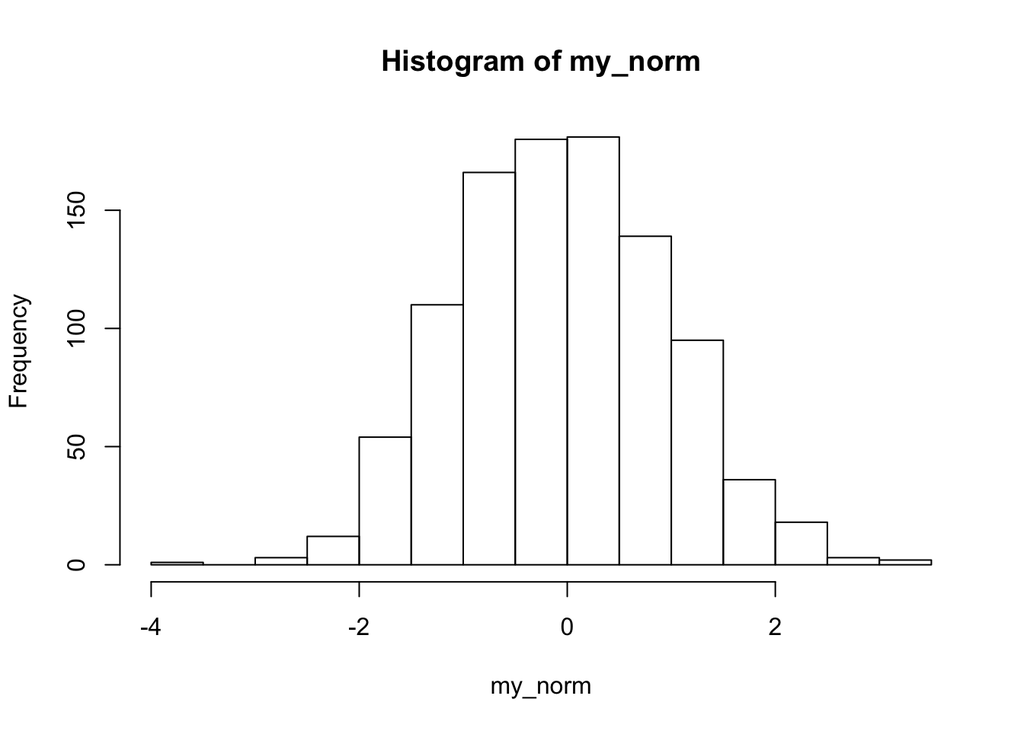

```r
hist(my_norm)
```

### 2.6. Subsetting Vectors

```
> swirl()
```

次のステップも同じですから、和訳や解説は省略します。

```
| Welcome to swirl! Please sign in. If you've been here before, use the same name as you did then.
| If you are new, call yourself something unique.

What shall I call you? SL

| Please choose a course, or type 0 to exit swirl.

1: R Programming
2: Take me to the swirl course repository!

Selection: 1

| Please choose a lesson, or type 0 to return to course menu.

 1: Basic Building Blocks      2: Workspace and Files        3: Sequences of Numbers
 4: Vectors                    5: Missing Values             6: Subsetting Vectors
 7: Matrices and Data Frames   8: Logic                      9: Functions
10: lapply and sapply         11: vapply and tapply         12: Looking at Data
13: Simulation                14: Dates and Times           15: Base Graphics


Selection: 6
```

6: Subsetting Vectors（第６課 ベクトルの部分抽出）を選択しました。

```
| In this lesson, we'll see how to extract elements from a vector based on some conditions that we
| specify.

...
```

*この課では、ある条件のもとで、vector（ベクトル）の一部分を抽出する方法を学びます。全部で4種類あります。*

```
| For example, we may only be interested in the first 20 elements of a vector, or only the
| elements that are not NA, or only those that are positive or correspond to a specific variable
| of interest. By the end of this lesson, you'll know how to handle each of these scenarios.

...
```

*たとえば、vector（ベクトル）の最初の20の成分が必要だとか、NA ではないものだけ必要だとか、値が正のものだけ抽出したいとか、特別な変数だけ取り出したいということです。この課の中で、皆さんは、このような場合をどのように扱うか学びます。*

```
| I've created for you a vector called x that contains a random ordering of 20 numbers (from a
| standard normal distribution) and 20 NAs. Type x now to see what it looks like.
```

*標準正規分布 (standard normal distribution) をしている20個の数と、20個の NA が無作為に並んだベクトル x を用意しました。x と入力して、見てみましょう。*

```
> x
 [1]           NA           NA  0.672175862           NA  0.008344719           NA           NA
 [8]  1.456607612 -0.407798133 -1.356906989 -0.117210236 -0.163337577           NA -1.089090700
[15] -0.780951863           NA           NA -0.236279138           NA           NA  1.442420911
[22]           NA  0.739574674           NA -0.512273194           NA  1.719594992           NA
[29]           NA           NA           NA  0.352762824           NA -0.775962958           NA
[36] -1.636275451  0.402442715  1.424962109 -0.525836783           NA

| That's a job well done!
```

*よくできました。*

```
| The way you tell R that you want to select some particular elements (i.e. a 'subset') from a
| vector is by placing an 'index vector' in square brackets immediately following the name of the
| vector.

...
```

*vector（ベクトル）の一部と取り出すには、そのベクトルのあとの square brackets（[], 学校教育では大括弧と読んでいます）の中に、‘index vector’（インデックス（指数）からなるベクトル）を書き舞うｓ。*

```
| For a simple example, try x[1:10] to view the first ten elements of x.
```

*まず、簡単な例として、x[1:10] を試し、x の最初の10個の要素を見てみましょ。*

```
> x[1:10]
 [1]           NA           NA  0.672175862           NA  0.008344719           NA           NA
 [8]  1.456607612 -0.407798133 -1.356906989

| All that hard work is paying off!
```

*努力は報われます。*

```
| Index vectors come in four different flavors -- logical vectors, vectors of positive integers,
| vectors of negative integers, and vectors of character strings -- each of which we'll cover in
| this lesson.

...
```

*インデックスベクトルには4種類あります。論理ベクトル、正の整数からなるベクトル、負の整数からなるベクトル、そして、文字列です。この課でこれらを学びましょう。*

```
| Let's start by indexing with logical vectors. One common scenario when working with real-world
| data is that we want to extract all elements of a vector that are not NA (i.e. missing data).
| Recall that is.na(x) yields a vector of logical values the same length as x, with TRUEs
| corresponding to NA values in x and FALSEs corresponding to non-NA values in x.

...
```

*まず、論理ベクトルからなるインデックスベクトルからはじめましょう。実社会のデータを扱っていると、NA（欠損値）以外の値を抽出したいことが起こります。is.na(x) は、x と同じ長さの、論理ベクトルで、NA に対応するところは、TRUE で、NA ではないところは、FALSE になっています。*

```
| What do you think x[is.na(x)] will give you?

1: A vector of length 0
2: A vector of TRUEs and FALSEs
3: A vector of all NAs
4: A vector with no NAs
```

*x[is.na(x)] はどのようなベクトルとなるでしょうか。1-4 の中から選んでください。1: 長さ 0 のベクトル、2: TRUE と FALSE がいくつか並んだベクトル、3: すべて NA からなるベクトル、4: NA が一つもないベクトル。*

```
Selection: 3

| Excellent job!
```

*素晴らしい。*

```
| Prove it to yourself by typing x[is.na(x)].
```

*x[is.na(x)] で、あなたの答えが正しいことを確認してください。*

```
> x[is.na(x)]
 [1] NA NA NA NA NA NA NA NA NA NA NA NA NA NA NA NA NA NA NA NA

| Excellent job!
```

*素晴らしい。*

```
| Recall that `!` gives us the negation of a logical expression, so !is.na(x) can be read as 'is
| not NA'. Therefore, if we want to create a vector called y that contains all of the non-NA
| values from x, we can use y <- x[!is.na(x)]. Give it a try.
```

*`!`は、論理表現の否定でした。ですから、!is.na(x) は、「NA ではない」と読むことができます。NA ではない値ばかりのベクトル y を作成してみましょう。それには、y <- x[!is.na(x)] とします。試してみてください。*

```
> y <- x[!is.na(x)]

| You got it right!
```

*その通りです。*

```
| Print y to the console.
```

*y を（コンピュータ）画面（concole モニター）に表示してください。*

```
> y
 [1]  0.672175862  0.008344719  1.456607612 -0.407798133 -1.356906989 -0.117210236 -0.163337577
 [8] -1.089090700 -0.780951863 -0.236279138  1.442420911  0.739574674 -0.512273194  1.719594992
[15]  0.352762824 -0.775962958 -1.636275451  0.402442715  1.424962109 -0.525836783

| Excellent job!
```

*素晴らしい。*

```
| Now that we've isolated the non-missing values of x and put them in y, we can subset y as we
| please.

...
```

*x の 欠損値以外を、分離して、y というベクトルとして抽出することができました。*

```
| Recall that the expression y > 0 will give us a vector of logical values the same length as y,
| with TRUEs corresponding to values of y that are greater than zero and FALSEs corresponding to
| values of y that are less than or equal to zero. What do you think y[y > 0] will give you?

1: A vector of all the positive elements of y
2: A vector of all NAs
3: A vector of TRUEs and FALSEs
4: A vector of all the negative elements of y
5: A vector of length 0
```

*y>0 は、y の値が正（0より大きい）ところはTRUE、値が負か0のところ（0以下）は FALSE となる、yと同じ長さのベクトルを与えます。では、y[y > 0] はどのようなベクトルになると思いますか。1-5 の中から選んでください。1: y のうち正の値のみからなるベクトル、2: すべて NA からなるベクトル、3: いくつかの TRUE と FALSE からなるベクトル、4: y のうち負の値のみからなるベクトル、5: 長さが0のベクトル。*

```
Selection: 1

| You are quite good my friend!
```

*いい具合ですね。*

```
| Type y[y > 0] to see that we get all of the positive elements of y, which are also the positive
| elements of our original vector x.
```

*y[y > 0] と入力して、y の値の内、正のもののみからなるベクトル、すなわち、最初の x の正の値のみからなるベクトルとなっていることを確認してください。*

```
> y[y > 0]
[1] 0.672175862 0.008344719 1.456607612 1.442420911 0.739574674 1.719594992 0.352762824 0.402442715
[9] 1.424962109

| All that practice is paying off!
```

*練習のおかげですね。*

```
| You might wonder why we didn't just start with x[x > 0] to isolate the positive elements of x.
| Try that now to see why.
```

*最初から、なぜ、x[x > 0] としないのかと思われる方もいるかもしれませんね。では、試してみましょう。*

```
> x[x > 0]
 [1]          NA          NA 0.672175862          NA 0.008344719          NA          NA
 [8] 1.456607612          NA          NA          NA          NA          NA 1.442420911
[15]          NA 0.739574674          NA          NA 1.719594992          NA          NA
[22]          NA          NA 0.352762824          NA          NA 0.402442715 1.424962109
[29]          NA

| Nice work!
```

*それで良いですよ。*

```
| Since NA is not a value, but rather a placeholder for an unknown quantity, the expression NA > 0
| evaluates to NA. Hence we get a bunch of NAs mixed in with our positive numbers when we do this.

...
```

*NA は値ではなく、その場所は、不明だと示すものなので、NA > 0 の値は、NA となります。したがって、結果は、正の数とともに、たくさんの NA を得ることとなりました。*

```
| Combining our knowledge of logical operators with our new knowledge of subsetting, we could do
| this -- x[!is.na(x) & x > 0]. Try it out.
```

*ベクトルの一部分を抽出することを学びましたが、論理演算で学んだこととあわせると、x[!is.na(x) & x > 0] でよいことがわかります。試してみてください。*

```
> x[!is.na(x) & x > 0]
[1] 0.672175862 0.008344719 1.456607612 1.442420911 0.739574674 1.719594992 0.352762824 0.402442715
[9] 1.424962109

| You are quite good my friend!
```

*いい具合ですね。*

```
| In this case, we request only values of x that are both non-missing AND greater than zero.

...
```

*今度は、x の値で、欠損値ではなく、かつ、正（0より大きい）ものを抽出することができました。*

```
| I've already shown you how to subset just the first ten values of x using x[1:10]. In this case,
| we're providing a vector of positive integers inside of the square brackets, which tells R to
| return only the elements of x numbered 1 through 10.

...
```

*すでに、x[1:10] で、最初の10個の値を抽出する方法を示しました。この場合は、square brackets（かっこ）の中には、正の数だけからなるベクトルが入っています。そして、x の 1 から 10 番目までの値を抽出するように、R に伝えています。*

```
| Many programming languages use what's called 'zero-based indexing', which means that the first
| element of a vector is considered element 0. R uses 'one-based indexing', which (you guessed
| it!) means the first element of a vector is considered element 1.

...
```

*プログラミング言語は多くの場合、インデックスは、0 からはじめます。すなわち、0番目を最初としますが、R では、みなさんもわかっているかもしれませんが、1 からはじめます。すなわち、1番目が最初です。*

```
| Can you figure out how we'd subset the 3rd, 5th, and 7th elements of x? Hint -- Use the c()
| function to specify the element numbers as a numeric vector.
```

*x の3番目、5番目、7番目を抽出する方法はわかりますか。ヒントは、c() を使って、何番目かを指定する、数ベクトルを使うことです。*

```
> x[c(3,5,7)]
[1] 0.672175862 0.008344719          NA

| Keep up the great work!
```

*その調子です。*

```
| It's important that when using integer vectors to subset our vector x, we stick with the set of
| indexes {1, 2, ..., 40} since x only has 40 elements. What happens if we ask for the zeroth
| element of x (i.e. x[0])? Give it a try.
```

_ベクトル x の一部分を取り出すとき、インデックス {1, 2, …, 40} の中から指定することは大切です。x は 40 個の成分からなっているからです。では、0 番目を指定したらどうなるでしょうか。x[0]_を試してみてください。

```
> x[0]
numeric(0)

| All that practice is paying off!
```

*練習のおかげですね。*

```
| As you might expect, we get nothing useful. Unfortunately, R doesn't prevent us from doing this.
| What if we ask for the 3000th element of x? Try it out.
```

*特に有用なものではありませんでした。しかし、R は、このようなことを禁止しているわけでもないこともわかりました。では、x の3000 番目要素はどうなるでしょうか。試してみてください。*

```
> x[3000]
[1] NA

| Keep working like that and you'll get there!
```

*その調子で良いですよ。*

```
| Again, nothing useful, but R doesn't prevent us from asking for it. This should be a cautionary
| tale. You should always make sure that what you are asking for is within the bounds of the
| vector you're working with.

...
```

*有効ではありませんが、R は、このようなことを禁止もしません。記憶に留めておくべき事ではあります。つねに、x のインデックスの範囲の値を抽出することを、大切なことです。*

```
| What if we're interested in all elements of x EXCEPT the 2nd and 10th? It would be pretty
| tedious to construct a vector containing all numbers 1 through 40 EXCEPT 2 and 10.

...
```

*では、x の 2番目と 10番目以外を抽出するときはどうしたらよいでしょうか。1 から 40 で、2 と 10 を除いた数からなるベクトルを作成するのは、面倒です。*

```
| Luckily, R accepts negative integer indexes. Whereas x[c(2, 10)] gives us ONLY the 2nd and 10th
| elements of x, x[c(-2, -10)] gives us all elements of x EXCEPT for the 2nd and 10 elements.  Try
| x[c(-2, -10)] now to see this.
```

*R では、負の数を、インデックスとして使うことができます。x[c(2, 10)] は、x の2番目と、10番目だけを抽出するのでしたが、x[c(-2, -10)] とすると、2番目と、10番目以外を抽出することができます。試してください。*

```
> x[c(-2, -10)]
 [1]           NA  0.672175862           NA  0.008344719           NA           NA  1.456607612
 [8] -0.407798133 -0.117210236 -0.163337577           NA -1.089090700 -0.780951863           NA
[15]           NA -0.236279138           NA           NA  1.442420911           NA  0.739574674
[22]           NA -0.512273194           NA  1.719594992           NA           NA           NA
[29]           NA  0.352762824           NA -0.775962958           NA -1.636275451  0.402442715
[36]  1.424962109 -0.525836783           NA

| All that hard work is paying off!
```

*努力は報われます。*

```
| A shorthand way of specifying multiple negative numbers is to put the negative sign out in front
| of the vector of positive numbers. Type x[-c(2, 10)] to get the exact same result.
```

*もう少し簡単な方法として、正の数からなるベクトルの先頭に、- を付けることも可能です。x[-c(2, 10)] でも同じ結果を得ます。*

```
> x[-c(2, 10)]
 [1]           NA  0.672175862           NA  0.008344719           NA           NA  1.456607612
 [8] -0.407798133 -0.117210236 -0.163337577           NA -1.089090700 -0.780951863           NA
[15]           NA -0.236279138           NA           NA  1.442420911           NA  0.739574674
[22]           NA -0.512273194           NA  1.719594992           NA           NA           NA
[29]           NA  0.352762824           NA -0.775962958           NA -1.636275451  0.402442715
[36]  1.424962109 -0.525836783           NA

| You got it right!
```

*その通りです。*

```
| So far, we've covered three types of index vectors -- logical, positive integer, and negative
| integer. The only remaining type requires us to introduce the concept of 'named' elements.

...
```

*これまで、インデックスを指定する三つの方法を学びました。論理値、正の整数、負の整数です。最後に、名前による抽出について学びましょう。*

```
| Create a numeric vector with three named elements using vect <- c(foo = 11, bar = 2, norf = NA).
```

*vect <- c(foo = 11, bar = 2, norf = NA) として、名前のついた、三つの要素からなるベクトルを作成しましょう。*

```
> vect <- c(foo = 11, bar = 2, norf = NA)

| All that practice is paying off!
```

*練習のおかげですね。*

```
| When we print vect to the console, you'll see that each element has a name. Try it out.
```

*Console（コンピュータ画面）に出力すると、それぞれに名前が付いていることがわかります。試してくさい。*

```
> vect
 foo  bar norf
  11    2   NA

| That's the answer I was looking for.
```

```
| Please choose a course, or type 0 to exit swirl.

1: R Programming
2: Take me to the swirl course repository!

Selection: 1

| Please choose a lesson, or type 0 to return to course menu.

 1: Basic Building Blocks      2: Workspace and Files        3: Sequences of Numbers
 4: Vectors                    5: Missing Values             6: Subsetting Vectors
 7: Matrices and Data Frames   8: Logic                      9: Functions
10: lapply and sapply         11: vapply and tapply         12: Looking at Data
13: Simulation                14: Dates and Times           15: Base Graphics


Selection: 11
```

11: vapply and tapply（第11課 vapply and tapply）を選択しました。

```
| In the last lesson, you learned about the two most fundamental members of R's *apply family of
| functions: lapply() and sapply(). Both take a list as input, apply a function to each element of
| the list, then combine and return the result. lapply() always returns a list, whereas sapply()
| attempts to simplify the result.

...
```

_前の課では、R の *apply 系列の二つの基本的な関数である、lapply() と sapply() について学びました。どちらも、list を入力し、リストのそれぞれの要素に関数を適用します。そして、結果を連結させて出力します。lapply() は常に、リストを返しますが、sapply() は、結果を簡単にすることを試みます。_

```
| In this lesson, you'll learn how to use vapply() and tapply(), each of which serves a very
| specific purpose within the Split-Apply-Combine methodology. For consistency, we'll use the same
| dataset we used in the 'lapply and sapply' lesson.

...
```

*この課では、vapply() と tapply() について学びます。どちらも、Split-Apply-Combine（分解して、適用して、連結させる）手法を実行します。続きであることを意識して、lapply() と sapply() を学んだときと同じデータセットを使います。*

```
| The Flags dataset from the UCI Machine Learning Repository contains details of various nations
| and their flags. More information may be found here:
| http://archive.ics.uci.edu/ml/datasets/Flags

...
```

*Flags データセットは、UCI Machine Learning Repository（カリフォルニア大学アーバイン校の機械学習のためのデータ庫）からのもので、http://archive.ics.uci.edu/ml/datasets/Flags に詳しい情報があります。*

```
| I've stored the data in a variable called flags. If it's been a while since you completed the
| 'lapply and sapply' lesson, you may want to reacquaint yourself with the data by using functions
| like dim(), head(), str(), and summary() when you return to the prompt (>). You can also type
| viewinfo() at the prompt to bring up some documentation for the dataset. Let's get started!

...
```

*flag という名前の変数にデータを割り当ててあります。‘lapply’ と ‘sapply’ を学んでしばらくたっているのであれば、（いったん、swirl から抜けて）Prompt (>) で、dim(), head(), str(), や summary() を試してください。また、viewinfo() として、このデータセットに関する文書をみてみるのも良いでしょう。はじめましょう。*

viewinfo() の情報は、flag.names.txt とというファイルにあり、その内容は、この課のノートの直前、前の課の最後に掲載してあります。また、この課の最後に、dim(), head(), str(), や summary() の結果の、Console Log を載せましたので、参考にしてください。

```
| As you saw in the last lesson, the unique() function returns a vector of the unique values
| contained in the object passed to it. Therefore, sapply(flags, unique) returns a list containing
| one vector of unique values for each column of the flags dataset. Try it again now.
```

*前の課で見たように、unique() 関数は、そのオブジェクトに含まれる相異なる値をベクトルにして返します。そこで、sapply(flags, unique) は、flag データセットの各列の相異なる値をベクトルにして、リストにまとめて返します。試してください。*

```
> sapply(flags, unique)
$name
  [1] Afghanistan              Albania                  Algeria
  [4] American-Samoa           Andorra                  Angola
  [7] Anguilla                 Antigua-Barbuda          Argentina
 [10] Argentine                Australia                Austria
 [13] Bahamas                  Bahrain                  Bangladesh
 [16] Barbados                 Belgium                  Belize
 [19] Benin                    Bermuda                  Bhutan
 [22] Bolivia                  Botswana                 Brazil
 [25] British-Virgin-Isles     Brunei                   Bulgaria
 [28] Burkina                  Burma                    Burundi
 [31] Cameroon                 Canada                   Cape-Verde-Islands
 [34] Cayman-Islands           Central-African-Republic Chad
 [37] Chile                    China                    Colombia
 [40] Comorro-Islands          Congo                    Cook-Islands
 [43] Costa-Rica               Cuba                     Cyprus
 [46] Czechoslovakia           Denmark                  Djibouti
 [49] Dominica                 Dominican-Republic       Ecuador
 [52] Egypt                    El-Salvador              Equatorial-Guinea
 [55] Ethiopia                 Faeroes                  Falklands-Malvinas
 [58] Fiji                     Finland                  France
 [61] French-Guiana            French-Polynesia         Gabon
 [64] Gambia                   Germany-DDR              Germany-FRG
 [67] Ghana                    Gibraltar                Greece
 [70] Greenland                Grenada                  Guam
 [73] Guatemala                Guinea                   Guinea-Bissau
 [76] Guyana                   Haiti                    Honduras
 [79] Hong-Kong                Hungary                  Iceland
 [82] India                    Indonesia                Iran
 [85] Iraq                     Ireland                  Israel
 [88] Italy                    Ivory-Coast              Jamaica
 [91] Japan                    Jordan                   Kampuchea
 [94] Kenya                    Kiribati                 Kuwait
 [97] Laos                     Lebanon                  Lesotho
[100] Liberia                  Libya                    Liechtenstein
[103] Luxembourg               Malagasy                 Malawi
[106] Malaysia                 Maldive-Islands          Mali
[109] Malta                    Marianas                 Mauritania
[112] Mauritius                Mexico                   Micronesia
[115] Monaco                   Mongolia                 Montserrat
[118] Morocco                  Mozambique               Nauru
[121] Nepal                    Netherlands              Netherlands-Antilles
[124] New-Zealand              Nicaragua                Niger
[127] Nigeria                  Niue                     North-Korea
[130] North-Yemen              Norway                   Oman
[133] Pakistan                 Panama                   Papua-New-Guinea
[136] Parguay                  Peru                     Philippines
[139] Poland                   Portugal                 Puerto-Rico
[142] Qatar                    Romania                  Rwanda
[145] San-Marino               Sao-Tome                 Saudi-Arabia
[148] Senegal                  Seychelles               Sierra-Leone
[151] Singapore                Soloman-Islands          Somalia
[154] South-Africa             South-Korea              South-Yemen
[157] Spain                    Sri-Lanka                St-Helena
[160] St-Kitts-Nevis           St-Lucia                 St-Vincent
[163] Sudan                    Surinam                  Swaziland
[166] Sweden                   Switzerland              Syria
[169] Taiwan                   Tanzania                 Thailand
[172] Togo                     Tonga                    Trinidad-Tobago
[175] Tunisia                  Turkey                   Turks-Cocos-Islands
[178] Tuvalu                   UAE                      Uganda
[181] UK                       Uruguay                  US-Virgin-Isles
[184] USA                      USSR                     Vanuatu
[187] Vatican-City             Venezuela                Vietnam
[190] Western-Samoa            Yugoslavia               Zaire
[193] Zambia                   Zimbabwe
194 Levels: Afghanistan Albania Algeria American-Samoa Andorra Angola Anguilla ... Zimbabwe

$landmass
[1] 5 3 4 6 1 2

$zone
[1] 1 3 2 4

$area
  [1]   648    29  2388     0  1247  2777  7690    84    19     1   143    31    23   113    47
 [16]  1099   600  8512     6   111   274   678    28   474  9976     4   623  1284   757  9561
 [31]  1139     2   342    51   115     9   128    43    22    49   284  1001    21  1222    12
 [46]    18   337   547    91   268    10   108   249   239   132  2176   109   246    36   215
 [61]   112    93   103  3268  1904  1648   435    70   301   323    11   372    98   181   583
 [76]   236    30  1760     3   587   118   333  1240  1031  1973  1566   447   783   140    41
 [91]  1267   925   121   195   324   212   804    76   463   407  1285   300   313    92   237
[106]    26  2150   196    72   637  1221    99   288   505    66  2506    63    17   450   185
[121]   945   514    57     5   164   781   245   178  9363 22402    15   912   256   905   753
[136]   391

$population
 [1]   16    3   20    0    7   28   15    8   90   10    1    6  119    9   35    4   24    2   11
[20] 1008    5   47   31   54   17   61   14  684  157   39   57  118   13   77   12   56   18   84
[39]   48   36   22   29   38   49   45  231  274   60

$language
 [1] 10  6  8  1  2  4  3  5  7  9

$religion
[1] 2 6 1 0 5 3 4 7

$bars
[1] 0 2 3 1 5

$stripes
 [1]  3  0  2  1  5  9 11 14  4  6 13  7

$colours
[1] 5 3 2 8 6 4 7 1

$red
[1] 1 0

$green
[1] 1 0

$blue
[1] 0 1

$gold
[1] 1 0

$white
[1] 1 0

$black
[1] 1 0

$orange
[1] 0 1

$mainhue
[1] green  red    blue   gold   white  orange black  brown
Levels: black blue brown gold green orange red white

$circles
[1] 0 1 4 2

$crosses
[1] 0 1 2

$saltires
[1] 0 1

$quarters
[1] 0 1 4

$sunstars
 [1]  1  0  6 22 14  3  4  5 15 10  7  2  9 50

$crescent
[1] 0 1

$triangle
[1] 0 1

$icon
[1] 1 0

$animate
[1] 0 1

$text
[1] 0 1

$topleft
[1] black  red    green  blue   white  orange gold
Levels: black blue gold green orange red white

$botright
[1] green  red    white  black  blue   gold   orange brown
Levels: black blue brown gold green orange red white


| Keep working like that and you'll get there!
```

*その調子で良いですよ。*

```
| What if you had forgotten how unique() works and mistakenly thought it returns the *number* of
| unique values contained in the object passed to it? Then you might have incorrectly expected
| sapply(flags, unique) to return a numeric vector, since each element of the list returned would
| contain a single number and sapply() could then simplify the result to a vector.

...
```

*たとえば、unique() がどのように作用するか忘れていて、渡したオブジェクトに含まれる相異なるものの**数**を返すと考えたとしましょう。すると、各値は、一つの数値ですから、sapply(flags, unique) は、簡単にして、ベクトルを返すと考えることになります。*

```
| When working interactively (at the prompt), this is not much of a problem, since you see the
| result immediately and will quickly recognize your mistake. However, when working
| non-interactively (e.g. writing your own functions), a misunderstanding may go undetected and
| cause incorrect results later on. Therefore, you may wish to be more careful and that's where
| vapply() is useful.

...
```

*Prompt に対話型で関数を入力し、作業を進めるときは、すぐに答えを見て、間違いに気づくので、あまり問題になりません。しかし、対話型ではなく、プログラムを書いて、作業を進めるときには、間違いに気づかずに過ぎてしまうかもしれません。従って、もっと、注意をする必要があります。このようなときに、vapply() は有効です。*

```
| Whereas sapply() tries to 'guess' the correct format of the result, vapply() allows you to
| specify it explicitly. If the result doesn't match the format you specify, vapply() will throw
| an error, causing the operation to stop. This can prevent significant problems in your code that
| might be caused by getting unexpected return values from sapply().

...
```

*sapply() では、結果の形式を推測して実行しますが、vapply() は明示的に、実行します。形式が適合しなければ、vapply() はエラーメッセージを出し、作業は停止します。これによって、sapply() が予想にない値を返し、重大な問題を生じることを避けることができます。*

```
| Try vapply(flags, unique, numeric(1)), which says that you expect each element of the result to
| be a numeric vector of length 1. Since this is NOT actually the case, YOU WILL GET AN ERROR.
| Once you get the error, type ok() to continue to the next question.
```

*vapply(flags, unique, numeric(1)) と入力しましょう。これは、結果が、長さが１の数値ベクトルを返す事を期待していることを意味します。これは、実際には、正しくないので、エラーをひきおこします。エラーになったら、ok() と入力すると、次の問題を続けることができます。*

```
> vapply(flags, unique, numeric(1))
Error in vapply(flags, unique, numeric(1)) : values must be length 1,
 but FUN(X[[1]]) result is length 194
[日本語の場合のエラーメッセージ] vapply(flags, unique, numeric(1)) でエラー:
   値の長さは 1 でなければなりません、
 しかし、FUN(X[[1]]) の結果の長さが 194 です

> ok()

| You are doing so well!
```

*とてもうまくいっていますよ。*

```
| Recall from the previous lesson that sapply(flags, class) will return a character vector
| containing the class of each column in the dataset. Try that again now to see the result.
```

*前の課で学んだように、sapply(flags, class) は、データセットの各列の種類（class）を表す文字列ベクトルを返すのでした。もう一度試してください。*

```
> sapply(flags, class)
      name   landmass       zone       area population   language   religion       bars    stripes
  "factor"  "integer"  "integer"  "integer"  "integer"  "integer"  "integer"  "integer"  "integer"
   colours        red      green       blue       gold      white      black     orange    mainhue
 "integer"  "integer"  "integer"  "integer"  "integer"  "integer"  "integer"  "integer"   "factor"
   circles    crosses   saltires   quarters   sunstars   crescent   triangle       icon    animate
 "integer"  "integer"  "integer"  "integer"  "integer"  "integer"  "integer"  "integer"  "integer"
      text    topleft   botright
 "integer"   "factor"   "factor"

| All that hard work is paying off!
```

*努力は報われます。*

```
| If we wish to be explicit about the format of the result we expect, we can use vapply(flags,
| class, character(1)). The 'character(1)' argument tells R that we expect the class function to
| return a character vector of length 1 when applied to EACH column of the flags dataset. Try it
| now.
```

*出力としてなにを期待しているかを明示的にするには、vapply(flags, class, character(1)) とします。引数の ‘character(1)’ は、R に、flag データセットの各列に、class 関数を適用した結果として、長さ 1 の文字列ベクトルを返すことを期待していると伝えています。試してください。*

```
> vapply(flags, class, character(1))
      name   landmass       zone       area population   language   religion       bars    stripes
  "factor"  "integer"  "integer"  "integer"  "integer"  "integer"  "integer"  "integer"  "integer"
   colours        red      green       blue       gold      white      black     orange    mainhue
 "integer"  "integer"  "integer"  "integer"  "integer"  "integer"  "integer"  "integer"   "factor"
   circles    crosses   saltires   quarters   sunstars   crescent   triangle       icon    animate
 "integer"  "integer"  "integer"  "integer"  "integer"  "integer"  "integer"  "integer"  "integer"
      text    topleft   botright
 "integer"   "factor"   "factor"

| You nailed it! Good job!
```

*見事です。*

```
| Note that since our expectation was correct (i.e. character(1)), the vapply() result is
| identical to the sapply() result -- a character vector of column classes.

...
```

*確かに、予測は正しく（character(1)）、vapply() は、sapply() と全く同じ結果、すなわち、各列の種類（class）を返しました。*

```
| You might think of vapply() as being 'safer' than sapply(), since it requires you to specify the
| format of the output in advance, instead of just allowing R to 'guess' what you wanted. In
| addition, vapply() may perform faster than sapply() for large datasets. However, when doing data
| analysis interactively (at the prompt), sapply() saves you some typing and will often be good
| enough.

...
```

*vapply() は、sapply() のように、R に、結果を推測させるのではなく、具体的な形式を前もって指定するので、より安全だと思うでしょう。さらに、vapply() は sapply() と比較して、特に大きなデータセットに対しては、実行速度が速いのです。しかし、Prompt に対して、対話型で、作業を進めるときは、sapply() は、入力を減らしますし、多くの場合、それで十分でもあります。*

```
| As a data analyst, you'll often wish to split your data up into groups based on the value of
| some variable, then apply a function to the members of each group. The next function we'll look
| at, tapply(), does exactly that.

...
```

*データ分析をしようとすると、まず、データを、ある変数の値によって、いくつかに分割し、分割したグループのそれぞれに、関数を適用したいことが起こります。次の関数 tapply() は、これから見ていくように、まさに、その作業をします。*

```
| Use ?tapply to pull up the documentation.
```

*?tapply として、説明の文書を表示してください。*

```
> ?tapply

| You are amazing!
```

*驚きです。*

```
| The 'landmass' variable in our dataset takes on integer values between 1 and 6, each of which
| represents a different part of the world. Use table(flags$landmass) to see how many
| flags/countries fall into each group.
```

*データセットの ‘landmass’ 変数は、1 から 6 の整数値をとり、世界の異なる地域を表します。table(flags$landmass) として、それぞれのグループにいくつの、flags/countries（国旗/国）があるか、見てみましょう。*

```
> table(flags$landmass)

 1  2  3  4  5  6
31 17 35 52 39 20

| That's a job well done!
```

*よくできました。*

```
| The 'animate' variable in our dataset takes the value 1 if a country's flag contains an animate
| image (e.g. an eagle, a tree, a human hand) and 0 otherwise. Use table(flags$animate) to see how
| many flags contain an animate image.
```

*データセットの ‘animate’ 変数は、その国の国旗が animate image（たとえば、わしや、木や、人間の手など）を含んでいれば 1、そうでなければ、0 となっています。table(flags$animate) として、いくつの国旗が、animate image を含んでいるか見てください。*

```
> table(flags$animate)

  0   1
155  39

| That's a job well done!
```

*よくできました。*

```
| This tells us that 39 flags contain an animate object (animate = 1) and 155 do not (animate =
| 0).

...
```

*39の旗は、animate object (animate = 1) を含んでおり、155 (animate = 0) は含んでいないことがわかりました。*

```
| If you take the arithmetic mean of a bunch of 0s and 1s, you get the proportion of 1s. Use
| tapply(flags$animate, flags$landmass, mean) to apply the mean function to the 'animate' variable
| separately for each of the six landmass groups, thus giving us the proportion of flags
| containing an animate image WITHIN each landmass group.
```

*0 と 1 の値の算術平均をとれば、1 の割合がわかります。tapply(flags$animate, flags$landmass, mean) として、6個の、landmass グループそれぞれについて別々に、‘animate’ 変数の mean（平均）をとってください。*

```
> tapply(flags$animate, flags$landmass, mean)
        1         2         3         4         5         6
0.4193548 0.1764706 0.1142857 0.1346154 0.1538462 0.3000000

| Perseverance, that's the answer.
```

*頑張りましたね。それが答えです。*

```
| The first landmass group (landmass = 1) corresponds to North America and contains the highest
| proportion of flags with an animate image (0.4194).

...
```

*最初の landmass グループ (landmass = 1) は、北アメリカで、一番高い、animate image の割合 (0.4194) になっています。*

```
| Similarly, we can look at a summary of population values (in round millions) for countries with
| and without the color red on their flag with tapply(flags$population, flags$red, summary).
```

*同様に、tapply(flags$population, flags$red, summary) で、旗に赤を含むか含まないかに分けて、人口を（100万人に四捨五入して）summary （要約）関数を使って求めてみましょう。*

```
> tapply(flags$population, flags$red, summary)
$`0`
   Min. 1st Qu.  Median    Mean 3rd Qu.    Max.
   0.00    0.00    3.00   27.63    9.00  684.00

$`1`
   Min. 1st Qu.  Median    Mean 3rd Qu.    Max.
    0.0     0.0     4.0    22.1    15.0  1008.0


| That's correct!
```

*正しいです。*

```
| What is the median population (in millions) for countries *without* the color red on their flag?

1: 4.0
2: 3.0
3: 0.0
4: 22.1
5: 27.6
6: 9.0
```

*赤を国旗に含まない国の中での人口（100万人に四捨五入）のメディアン（中央値）は何ですか。次から選んでください。1: 4.0, 2: 3.0, 3: 0.0, 4:22.1, 5: 27.6, 6:9.0.*

```
Selection: 2

| You got it!
```

*その通りです。*

```
| Lastly, use the same approach to look at a summary of population values for each of the six
| landmasses.
```

*最後に、同じ方法で、それぞれの 6種類の landmasses グループごとに、人口についての要約（summary）を求めてください。*

```
> tapply(flags$population, flags$landmass, summary)
$`1`
   Min. 1st Qu.  Median    Mean 3rd Qu.    Max.
   0.00    0.00    0.00   12.29    4.50  231.00

$`2`
   Min. 1st Qu.  Median    Mean 3rd Qu.    Max.
   0.00    1.00    6.00   15.71   15.00  119.00

$`3`
   Min. 1st Qu.  Median    Mean 3rd Qu.    Max.
   0.00    0.00    8.00   13.86   16.00   61.00

$`4`
   Min. 1st Qu.  Median    Mean 3rd Qu.    Max.
  0.000   1.000   5.000   8.788   9.750  56.000

$`5`
   Min. 1st Qu.  Median    Mean 3rd Qu.    Max.
   0.00    2.00   10.00   69.18   39.00 1008.00

$`6`
   Min. 1st Qu.  Median    Mean 3rd Qu.    Max.
   0.00    0.00    0.00   11.30    1.25  157.00


| That's the answer I was looking for.
```

*そうです。それが、期待したものです。*

```
| What is the maximum population (in millions) for the fourth landmass group (Africa)?

1: 1010.0
2: 119.0
3: 5.00
4: 56.00
5: 157.00
```

*4番目の landmass グループ（アフリカ）の最大の人口（100万人に四捨五入）は何ですか。次から選んでください。1: 1010.0, 2: 119.0, 3: 5.00, 4: 56.00, 5: 157.00*

```
Selection: 4

| All that hard work is paying off!
```

*努力は報われます。*

```
| In this lesson, you learned how to use vapply() as a safer alternative to sapply(), which is
| most helpful when writing your own functions. You also learned how to use tapply() to split your
| data into groups based on the value of some variable, then apply a function to each group. These
| functions will come in handy on your quest to become a better data analyst.

...
```

*この課では、vapply() は、sapply() の代わりとして使えるより安全な命令で、特に、プログラムを書くときに有効であることを学びました。また、tappy() 関数によって、ある変数の値によってグループに分けたデータについて、それぞれの、グループに関数を適用することに用いることを学びました。これらは、データ分析をするときに、とても、便利な関数です。*

```
  |=========================================================================================| 100%
| Would you like to receive credit for completing this course on Coursera.org?

1: No
2: Yes

Selection: 1
```

*Coursera.org の終了認定が欲しいですか。*

1 を選んでください。何度か説明しましたから、省略します。

```
| Great job!

| You've reached the end of this lesson! Returning to the main menu...

| Please choose a course, or type 0 to exit swirl.

1: R Programming
2: Take me to the swirl course repository!

Selection: 0
```

*やりましたね。*

*課の最後までたどり着きました。メニューに戻るには、*

*コースを選択してください。swirl を終了するときは、0 を入力してください。*

*1: R によるプログラム*  
*2: ｀swirl` コースのリストへ.*

*選択：0 （SL が入力）*

```
| Leaving swirl now. Type swirl() to resume.
```

*swirl を終了します。再開するときは、swirl() と入力してください。*

```
>
```

```
| We can also get the names of vect by passing vect as an argument to the names() function. Give
| that a try.
```

*names() 関数を使い、vect を argument（引数）とすることで、vect の 名前を得ることもできます。試してください。*

```
> names(vect)
[1] "foo"  "bar"  "norf"

| Nice work!
```

*それで良いですよ。*

```
| Alternatively, we can create an unnamed vector vect2 with c(11, 2, NA). Do that now.
```

*代わりに、c(11, 2, NA) として、名前なしのベクトル、vect2 を作成してみます。試してください。*

```
> vect2 <- c(11, 2, NA)

| That's the answer I was looking for.
```

*そうです。それが、期待したものです。*

```
| Then, we can add the `names` attribute to vect2 after the fact with names(vect2) <- c("foo",
| "bar", "norf"). Go ahead.
```

*今度は、vect2 に 属性 `names` を、names(vect2) <- c(“foo”,“bar”, “norf”) で付加することができます。試してください。*

```
> names(vect2) <- c("foo", "bar", "norf")

| You are really on a roll!
```

*どんどん学んでいますね。*

```
| Now, let's check that vect and vect2 are the same by passing them as arguments to the
| identical() function.
```

*では、vect と vect2 を arguments（引数）として、関数 identical() を使って、これらが全く等しいことを確かめてください。*

```
> identical(vect, vect2)
[1] TRUE

| Great job!
```

*やりましたね。*

```
| Indeed, vect and vect2 are identical named vectors.

...
```

*まさに、vect と vect2 は全く同じベクトルです。*

```
| Now, back to the matter of subsetting a vector by named elements. Which of the following
| commands do you think would give us the second element of vect?

1: vect[bar]
2: vect["2"]
3: vect["bar"]
```

*ベクトルの一部を抽出することに戻りました。vect の2番目の成分を取り出す命令は、どれだと思いますか。*

[output not shown]

*素晴らしい。*

```
| Now, try it out.
```

*では、試してください。*

```
> vect["bar"]
bar
  2

| Nice work!
```

*それで良いですよ。*

```
| Likewise, we can specify a vector of names with vect[c("foo", "bar")]. Try it out.
```

*同じように、vect[c(“foo”, “bar”)] のように使うこともできます。試してください。*

```
> vect[c("foo", "bar")]
foo bar
 11   2

| Keep working like that and you'll get there!
```

*その調子で良いですよ。*

```
  |=======================================================================================  |  97%
| Now you know all four methods of subsetting data from vectors. Different approaches are best in
| different scenarios and when in doubt, try it out!

...
```

*これで、ベクトルの一部を取り出す、四つの方法を学びました。それぞれの異なる状況で、最善となる、異なる方法がありますよ。信じられなければ、試してみてください。*

```
  |=========================================================================================| 100%
| Would you like to receive credit for completing this course on Coursera.org?

1: Yes
2: No

Selection: 2
```

*Coursera.org の終了認定が欲しいですか。*

_2 を選んでください。何度か説明しましたから、省略します。

```
| All that practice is paying off!

| You've reached the end of this lesson! Returning to the main menu...

| Please choose a course, or type 0 to exit swirl.

1: R Programming
2: Take me to the swirl course repository!

Selection: 0
```

*練習のおかげですね。*

*課の最後までたどり着きました。メニューに戻るには、*

*コースを選択してください。swirl を終了するときは、0 を入力してください。*

*1: R によるプログラム*  
*2: ｀swirl` コースのリストへ.*

*選択：0 （SL が入力）*

```
| Leaving swirl now. Type swirl() to resume.
```

*swirl を終了します。再開するときは、swirl() と入力してください。*

```
>
```

**x のようなベクトルの作成の仕方**

```
I've created for you a vector called x that contains a random ordering of 20 numbers (from a standard normal distribution) and 20 NAs.
```

```r
sample(c(rnorm(20), rep(NA, 20)), 40)
```

```
##  [1]  0.14462096 -0.08856425          NA -0.47243334          NA          NA
##  [7]  0.86773240          NA          NA          NA          NA -1.92900295
## [13]  0.55204295 -2.13654775 -2.05884511 -0.11510149          NA -2.50124986
## [19]  0.50170232          NA          NA          NA  0.62489499  0.53184693
## [25]          NA -0.23989142  0.03752504          NA  1.63335356          NA
## [31]  1.91367432          NA -0.39095489          NA          NA          NA
## [37]          NA -1.10218786          NA -0.84956330
```

### 2.7. Matrices and Data Frames

> vectors（ベクトル）の拡張として、matrices（行列）と、R で最も基本的な、データ形式である、Data Frames（データフレーム）について学びます。Data Frames（データフレーム）についてしっかり理解してください。  
> swirl() ではじめるところから、解説します。最初に、swirl を Install したり、library(swirl) を実行する部分は、省略します。よくわからない方は、1.2 または、1.1 の最初の部分を復習してください。

```
> swirl()
```

次のステップも同じですから、和訳や解説は省略します。

```
| Welcome to swirl! Please sign in. If you've been here before, use the same name as you did then.
| If you are new, call yourself something unique.

What shall I call you? SL

| Please choose a course, or type 0 to exit swirl.

1: R Programming
2: Take me to the swirl course repository!

Selection: 1

| Please choose a lesson, or type 0 to return to course menu.

 1: Basic Building Blocks      2: Workspace and Files        3: Sequences of Numbers
 4: Vectors                    5: Missing Values             6: Subsetting Vectors
 7: Matrices and Data Frames   8: Logic                      9: Functions
10: lapply and sapply         11: vapply and tapply         12: Looking at Data
13: Simulation                14: Dates and Times           15: Base Graphics


Selection: 7
```

7: Matrices and Data Frames（第７課 行列とデータフレーム）を選択しました。

```
| In this lesson, we'll cover matrices and data frames. Both represent 'rectangular' data types,
| meaning that they are used to store tabular data, with rows and columns.

...
```

*この課では、行列（matrices）と データフレーム（data frame）について学びます。どちらも、長方形（rectangular）をしたデータ型で、行と列からなる表を保存することができます。*

```
| The main difference, as you'll see, is that matrices can only contain a single class of data,
| while data frames can consist of many different classes of data.

...
```

*なにが異なるかは、いずれわかりますが、行列は、一種類（クラス）のデータしか持てませんが、データフレームは、いくつもの種類（クラス）のデータを含むことができます。*

```
| Let's create a vector containing the numbers 1 through 20 using the `:` operator. Store the
| result in a variable called my_vector.
```

*1から20からなるベクトルを `:` で作成し、結果を my_vector という名前に割り当てましょう。*

```
> my_vector <- 1:20

| Keep up the great work!
```

*その調子です。*

```
| View the contents of the vector you just created.
```

*いま作成したベクトルの中身を見てみましょう。*

```
> my_vector
 [1]  1  2  3  4  5  6  7  8  9 10 11 12 13 14 15 16 17 18 19 20

| Your dedication is inspiring!
```

*感動ものです。*

```
| The dim() function tells us the 'dimensions' of an object. What happens if we do dim(my_vector)?
| Give it a try.
```

*dim() 関数は、オブジェクトの ‘dimensions’ （次元）を教えてくれます。dim(my_vector) とするとどうなりますか。試してください。*

```
> dim(my_vector)
NULL

| Keep up the great work!
```

*その調子です。*

```
| Clearly, that's not very helpful! Since my_vector is a vector, it doesn't have a `dim` attribute
| (so it's just NULL), but we can find its length using the length() function. Try that now.
```

*あまり助けになりませんね。my_vector は、ベクトルですから、`dim` という属性を持っていません。（そこで、 NULL ’なし’でした）長さは length() 関数で調べることができます。試してください。*

```
> length(my_vector)
[1] 20

| Excellent job!
```

*素晴らしい。*

```
| Ah! That's what we wanted. But, what happens if we give my_vector a `dim` attribute? Let's give
| it a try. Type dim(my_vector) <- c(4, 5).
```

*それが求めるものでした。では、my_vector に `dim` 属性を付加したらどうなるでしょうか。試してみましょう。dim(my_vector) <- c(4, 5) と入力します。*

```
> dim(my_vector) <- c(4, 5)

| Great job!
```

*やりましたね。*

```
| It's okay if that last command seemed a little strange to you. It should! The dim() function
| allows you to get OR set the `dim` attribute for an R object. In this case, we assigned the
| value c(4, 5) to the `dim` attribute of my_vector.

...
```

*いま使った命令はなにか奇妙に感じるかもしれませんね。たしかにそうです。dim() 関数は、R のオブジェクトに、`dim`（次元）属性を付加します。この場合は、my_vector に、`dim`（次元）属性を、c(4,5) としました。*

```
| Use dim(my_vector) to confirm that we've set the `dim` attribute correctly.
```

*dim(my_vector) を使って、`dim`（次元）属性を正しく付加したことを確認してください。*

```
> dim(my_vector)
[1] 4 5

| Excellent job!
```

*素晴らしい。*

```
| Another way to see this is by calling the attributes() function on my_vector. Try it now.
```

*他の方法としては、attributes() 関数を使って、my_vector の属性を見ることもできます。試してください。*

```
> attributes(my_vector)
$dim
[1] 4 5

| You are quite good my friend!
```

*いい具合ですね。*

```
| Just like in math class, when dealing with a 2-dimensional object (think rectangular table), the
| first number is the number of rows and the second is the number of columns. Therefore, we just
| gave my_vector 4 rows and 5 columns.

...
```

*数学のクラスのように、二次元のオブジェクト（長方形の表のようなもの）を扱うときには、最初の数は「行 (row)」、二番目の数は「列 (column)」を表します。従って、my_vector は、4行、5列 としました。*

```
| But, wait! That doesn't sound like a vector any more. Well, it's not. Now it's a matrix. View
| the contents of my_vector now to see what it looks like.
```

*ちょっと待ってください。もう、ベクトルらしくないですね。今や行列です。my_vector の中身を表示させて、どのようになっているか見てみましょう。*

```
> my_vector
     [,1] [,2] [,3] [,4] [,5]
[1,]    1    5    9   13   17
[2,]    2    6   10   14   18
[3,]    3    7   11   15   19
[4,]    4    8   12   16   20

| That's correct!
```

*正しいです。*

```
| Now, let's confirm it's actually a matrix by using the class() function. Type class(my_vector)
| to see what I mean.
```

```
> class(my_vector)
[1] "matrix"

| You're the best!
```

*最高です。*

```
| Sure enough, my_vector is now a matrix. We should store it in a new variable that helps us
| remember what it is. Store the value of my_vector in a new variable called my_matrix.
```

```
> my_matrix <- my_vector

| That's a job well done!
```

*よくできました。*

```
| The example that we've used so far was meant to illustrate the point that a matrix is simply an
| atomic vector with a dimension attribute. A more direct method of creating the same matrix uses
| the matrix() function.

...
```

*この例から、行列は、単に atomic vector で次元という属性を持つものであることがわかりました。行列を作成する、もっと直接的な方法は、matrix() 関数を使うことです。*

```
| Bring up the help file for the matrix() function now using the `?` function.
```

*`?` 関数を使って、matrix() 関数の Help を見てください。*

```
> ?matrix

| All that hard work is paying off!
```

*努力は報われます。*

```
| Now, look at the documentation for the matrix function and see if you can figure out how to
| create a matrix containing the same numbers (1-20) and dimensions (4 rows, 5 columns) by calling
| the matrix() function. Store the result in a variable called my_matrix2.
```

*行列関数の Help を見て、同じ 1-20 のを成分とする、次元（4行、5列）の行列を matrix() 関数を使って作成し、それに、my_matrix2 という名前をつけてください。*

```
> my_matrix2 <- matrix(1:20, nrow = 4, ncol = 5)

| You nailed it! Good job!
```

*見事です。*

```
| Finally, let's confirm that my_matrix and my_matrix2 are actually identical. The identical()
| function will tell us if its first two arguments are the same. Try it out.
```

*最後に、my_matrix と my_matrix2 が確かに同じであることを、identical() 関数で確かめましょう。試してください。*

```
> identical(my_matrix, my_matrix2)
[1] TRUE

| Nice work!
```

*それで良いですよ。*

```
| Now, imagine that the numbers in our table represent some measurements from a clinical
| experiment, where each row represents one patient and each column represents one variable for
| which measurements were taken.

...
```

*いま、我々の表の値は、なんらかの、医学実験の測定値を表し、行は一人の患者のデータを表すとします。列は、測定変数を表すと考えましょう。*

```
| We may want to label the rows, so that we know which numbers belong to each patient in the
| experiment. One way to do this is to add a column to the matrix, which contains the names of all
| four people.

...
```

*行に名前を付けましょう。行は各患者のデータでした。それぞれの患者の名前からなる、新しく列を加えるのが一つの方法です。*

```
| Let's start by creating a character vector containing the names of our patients -- Bill, Gina,
| Kelly, and Sean. Remember that double quotes tell R that something is a character string. Store
| the result in a variable called patients.
```

*まず、Bill, Gina, Kelly, と Sean からなる、文字列ベクトルを作成しましょう。文字列であることを R に伝えるには、二重引用符 " で囲むのでしたね。patients という名前を割り当ててください。*

```
> patients <- c("Bill", "Gina", "Kelly", "Sean")

| You got it right!
```

*その通りです。*

```
| Now we'll use the cbind() function to 'combine columns'. Don't worry about storing the result in
| a new variable. Just call cbind() with two arguments -- the patients vector and my_matrix.
```

*次に、列を連結する cbind() 関数を使います。patients ベクトルと、my_matrix をcbind() の引数とします。*

```
> cbind(patients, my_matrix)
     patients
[1,] "Bill"   "1" "5" "9"  "13" "17"
[2,] "Gina"   "2" "6" "10" "14" "18"
[3,] "Kelly"  "3" "7" "11" "15" "19"
[4,] "Sean"   "4" "8" "12" "16" "20"

| That's the answer I was looking for.
```

*そうです。それが、期待したものです。*

```
| Something is fishy about our result! It appears that combining the character vector with our
| matrix of numbers caused everything to be enclosed in double quotes. This means we're left with
| a matrix of character strings, which is no good.

...
```

*結果は、ちょっと気持ちが悪いですね。文字列ベクトルと、連結され、行列の成分の数値がすべて、二重引用符で囲まれました。これは、行列が、文字列からなるものになったと言うことです。それは、良くありませんね。*

```
| If you remember back to the beginning of this lesson, I told you that matrices can only contain
| ONE class of data. Therefore, when we tried to combine a character vector with a numeric matrix,
| R was forced to 'coerce' the numbers to characters, hence the double quotes.

...
```

*この課の最初に、行列のデータは一種類（クラス）のみであると言いました。そこで、文字ベクトルを数ベクトルと組み合わせたときに、R は強制的に、数を文字列に変更し、結果として、二重引用符で囲まれました。*

```
| This is called 'implicit coercion', because we didn't ask for it. It just happened. But why
| didn't R just convert the names of our patients to numbers? I'll let you ponder that question on
| your own.

...
```

*これは、implicit coercion（暗黙の強制）と言われます。そのように、頼んで変化したからではないからです。では、なぜ、R は、患者の名前を数に変えなかったのでしょうか。それは、皆さんが考えてください。*

```
| So, we're still left with the question of how to include the names of our patients in the table
| without destroying the integrity of our numeric data. Try the following -- my_data <-
| data.frame(patients, my_matrix)
```

*結局、表に、数データをそのまま壊すことなく、どうやって患者の名前を加えるかという課題は、解決していません。次を試してください。my_data <- data.frame(patients, my_matrix)* _

```
> my_data <- data.frame(patients, my_matrix)

| Keep working like that and you'll get there!
```

*その調子で良いですよ。*

```
| Now view the contents of my_data to see what we've come up with.
```

*では、my_data のないようがどうなっているか見てみましょう。*

```
> my_data
  patients X1 X2 X3 X4 X5
1     Bill  1  5  9 13 17
2     Gina  2  6 10 14 18
3    Kelly  3  7 11 15 19
4     Sean  4  8 12 16 20

| Excellent work!
```

*素晴らしい。*

```
| It looks like the data.frame() function allowed us to store our character vector of names right
| alongside our matrix of numbers. That's exactly what we were hoping for!

...
```

*どうやら、data.frame() 関数は、文字列ベクトルを、数からなる行列と一緒に保存することができたようです。それが、まさに、希望していた事です。*

```
| Behind the scenes, the data.frame() function takes any number of arguments and returns a single
| object of class `data.frame` that is composed of the original objects.

...
```

*data.frame() 関数は、いくつもの arguments（因数）をまとめて、一つの `data.frame`（データフレーム）というクラスのオブジェクトにしています。*

```
| Let's confirm this by calling the class() function on our newly created data frame.
```

*このことを、いま作成したデータフレームについて、class() 関数で確かめてみましょう。*

```
> class(my_data)
[1] "data.frame"

| Great job!
```

*やりましたね。*

```
| It's also possible to assign names to the individual rows and columns of a data frame, which
| presents another possible way of determining which row of values in our table belongs to each
| patient.

...
```

*各行や、各列に名前をつけることができます。それによって、表のどの行の値が、どの患者のものかわかります。*

```
| However, since we've already solved that problem, let's solve a different problem by assigning
| names to the columns of our data frame so that we know what type of measurement each column
| represents.

...
```

*この課題はすでに解決しましたから、異なるもの、つまり、データフレームの列に、測定値の名前を付けてみましょう。*

```
| Since we have six columns (including patient names), we'll need to first create a vector
| containing one element for each column. Create a character vector called cnames that contains
| the following values (in order) -- "patient", "age", "weight", "bp", "rating", "test".
```

*患者名を含めて全部で6列ありますから、各列に対応するベクトルを作成しましょう。cname という名前で、“patient”, “age”, “weight”, “bp”, “rating”, “test” がこの順で並んでいる文字列ベクトルを作成してください。*

```
> cnames <- c("patient", "age", "weight", "bp", "rating", "test")

| Great job!
```

*やりましたね。*

```
| Now, use the colnames() function to set the `colnames` attribute for our data frame. This is
| similar to the way we used the dim() function earlier in this lesson.
```

*では、colnames() 関数を使って、データフレームに、`colnames` という属性を付加してください。これは、この課の中で、以前、dim() 関数を使ったときと同じです。*

```
> colnames(my_data) <- cnames

| Keep working like that and you'll get there!
```

*その調子で良いですよ。*

```
| Let's see if that got the job done. Print the contents of my_data.
```

*では、うまくいっているか、my_data の中身を表示させてください。*

```
> my_data
  patient age weight bp rating test
1    Bill   1      5  9     13   17
2    Gina   2      6 10     14   18
3   Kelly   3      7 11     15   19
4    Sean   4      8 12     16   20

| You got it!
```

*その通りです。*

```
  |=======================================================================================  |  97%
| In this lesson, you learned the basics of working with two very important and common data
| structures -- matrices and data frames. There's much more to learn and we'll be covering more
| advanced topics, particularly with respect to data frames, in future lessons.

...
```

*この課では、二つの標準的なデータ構造について学びました。matrices（行列）と data frame（データフレーム）ですね。特に、データフレームについて、今後、もっと詳しく学びます。*

```
  |=========================================================================================| 100%
| Would you like to receive credit for completing this course on Coursera.org?

1: No
2: Yes

Selection: 1
```

*Coursera.org の終了認定が欲しいですか。*

*1 を選んでください。何度か説明しましたから、省略します。*

```
| You're the best!

| You've reached the end of this lesson! Returning to the main menu...

| Please choose a course, or type 0 to exit swirl.

1: R Programming
2: Take me to the swirl course repository!

Selection: 0
```

*最高です。*

*課の最後までたどり着きました。メニューに戻るには、*

*コースを選択してください。swirl を終了するときは、0 を入力してください。*

*1: R によるプログラム*  
*2: ｀swirl` コースのリストへ.*

*選択：0 （SL が入力）*

```
| Leaving swirl now. Type swirl() to resume.
```

*swirl を終了します。再開するときは、swirl() と入力してください。*

```
>
```

### 2.8. Logic

> すでに第4課で少し学んだ論理について、続けて学びます。今後、条件を満たすデータフレームの行を取り出したり、流れの制御をする上で、必要になります。少し、複雑ですが、紙と鉛筆や、RStudio をもう一つ開いて、実験を重ねながら、練習問題に取り組んでください。  
> swirl() ではじめるところから、解説します。最初に、swirl を Install したり、library(swirl) を実行する部分は、省略します。よくわからない方は、1.2 または、1.1 の最初の部分を復習してください。

```
> swirl()
```

次のステップも同じですから、和訳や解説は省略します。

```
| Welcome to swirl! Please sign in. If you've been here before, use the same name as you did then.
| If you are new, call yourself something unique.

What shall I call you? SL

| Please choose a course, or type 0 to exit swirl.

1: R Programming
2: Take me to the swirl course repository!

Selection: 1

| Please choose a lesson, or type 0 to return to course menu.

 1: Basic Building Blocks      2: Workspace and Files        3: Sequences of Numbers
 4: Vectors                    5: Missing Values             6: Subsetting Vectors
 7: Matrices and Data Frames   8: Logic                      9: Functions
10: lapply and sapply         11: vapply and tapply         12: Looking at Data
13: Simulation                14: Dates and Times           15: Base Graphics


Selection: 8
```

8: Logic（第８課 論理）を選択しました。

```
| This lesson is meant to be a short introduction to logical operations in R.

...
```

*この課では、R の論理演算について、簡単に学びます。*

```
| There are two logical values in R, also called boolean values. They are TRUE and FALSE. In R you
| can construct logical expressions which will evaluate to either TRUE or FALSE.

...
```

*R には、二つの論理値があり、ブール値（boolean values）とも言います。R の論理式（表現）を構成し、TRUE か FALSE かの値を得ます。*

```
| Many of the questions in this lesson will involve evaluating logical expressions. It may be
| useful to open up a second R terminal where you can experiment with some of these expressions.

...
```

*この課の練習問題には、論理値を計算するものがたくさんあります。もう一つ、R の端末を開いて、実験しながら、進めることをお勧めします。*

```
| Creating logical expressions requires logical operators. You're probably familiar with
| arithmetic operators like `+`, `-`, `*`, and `/`. The first logical operator we are going to
| discuss is the equality operator, represented by two equals signs `==`. Use the equality
| operator below to find out if TRUE is equal to TRUE.
```

*論理式には、論理演算子を使います。数の計算で、`+`, `-`, `*`, や `/` を使うことには慣れていると思います。最初に学ぶのは、等価であることを示す論理の等号 `==` です。この等号を用いて、TRUE が TRUE と等価であることを確認してください。*

```
> TRUE == TRUE
[1] TRUE

| You are really on a roll!
```

*どんどん学んでいますね。*

```
| Just like arithmetic, logical expressions can be grouped by parenthesis so that the entire
| expression (TRUE == TRUE) == TRUE evaluates to TRUE.

...
```

*（数の）算術計算のときと同じように、論理式は、括弧でグループにします。(TRUE == TRUE) == TRUE は、TRUE となります。*

```
| To test out this property, try evaluating (FALSE == TRUE) == FALSE .
```

*この性質を確認するために、(FALSE == TRUE) == FALSE を試してください。*

```
> (FALSE == TRUE) == FALSE
[1] TRUE

| You got it right!
```

*その通りです。*

```
| The equality operator can also be used to compare numbers. Use `==` to see if 6 is equal to 7.
```

*等価演算子は、数の比較にも使えます。`==` を使って、6 が 7 と等しいか確認してください。*

```
> 6 == 7
[1] FALSE

| You're the best!
```

*最高です。*

```
| The previous expression evaluates to FALSE because 6 is less than 7. Thankfully, there are
| inequality operators that allow us to test if a value is less than or greater than another
| value.

...
```

*前の式では、6 は 7 より小さいので、等価ではなく、FALSE となりました。よりちいさいをあらわす不等号演算子もあります。*

```
| The less than operator `<` tests whether the number on the left side of the operator (called the
| left operand) is less than the number on the right side of the operator (called the right
| operand). Write an expression to test whether 6 is less than 7.
```

*よりちいさいを表す演算子は `<` で、演算子の左がわの数（左項 the left operand）が右側の数（右項 the right operand）より小さいかを調べます。6 は 7 より小さいは、どう書きますか。*

```
> 6 < 7
[1] TRUE

| Excellent job!
```

*素晴らしい。*

```
| There is also a less-than-or-equal-to operator `<=` which tests whether the left operand is less
| than or equal to the right operand. Write an expression to test whether 10 is less than or equal
| to 10.
```

*他に、左項は右項より小さいか等しい（以下）を表す、`<=` もあります。10 は 10 以下かを表す論理式を書いてください。*

```
> 10 <= 10
[1] TRUE

| Keep up the great work!
```

*その調子です。*

```
| Keep in mind that there are the corresponding greater than `>` and greater-than-or-equal-to `>=`
| operators.

...
```

*これらと対応して、より大きいを表す `>` と より大きいか等しい（以上）を表す `>=` もあります。*

```
| Which of the following evaluates to FALSE?

1: 7 == 7
2: 9 >= 10
3: 6 < 8
4: 0 > -36
```

*値が、FALSE となるのは、どれですか。*

```
Selection: 2

| Nice work!
```

*それで良いですよ。*

```
| Which of the following evaluates to TRUE?

1: 7 == 9
2: 57 < 8
3: -6 > -7
4: 9 >= 10
```

*値が、TRUE となるのは、どれですか。*

```
Selection: 3

| Keep up the great work!
```

*その調子です。*

```
| The next operator we will discuss is the 'not equals' operator represented by `!=`. Not equals
| tests whether two values are unequal, so TRUE != FALSE evaluates to TRUE. Like the equality
| operator, `!=` can also be used with numbers. Try writing an expression to see if 5 is not equal
| to 7.
```

*次は、等しくない (‘not equals’) を表す演算子 `!=` です。値が等しくないときに、TRUE となりますから、TRUE != FALSE は、TRUE です。等号と同じように、`!=` も数にも使えます。5 は 7 とは等しくないことを、確認してください。*

```
> 5 != 7
[1] TRUE

| You are really on a roll!
```

*どんどん学んでいますね。*

```
| In order to negate boolean expressions you can use the NOT operator. An exclamation point `!`
| will cause !TRUE (say: not true) to evaluate to FALSE and !FALSE (say: not false) to evaluate to
| TRUE. Try using the NOT operator and the equals operator to find the opposite of whether 5 is
| equal to 7.
```

*ブール表現（boolean expressions （二値）論理式）を否定するには、否定演算子 `!` を使います。!TRUE (not true と読みます) は、FALSE となり、!FALSE (not false と読みます) は、TRUE となります。否定演算子と等号を使って、5 は 7 と等しいの否定はどうなるか見てください。*

```
> !(5 == 7)
[1] TRUE

| Keep up the great work!
```

*その調子です。*

```
| Let's take a moment to review. The equals operator `==` tests whether two boolean values or
| numbers are equal, the not equals operator `!=` tests whether two boolean values or numbers are
| unequal, and the NOT operator `!` negates logical expressions so that TRUE expressions become
| FALSE and FALSE expressions become TRUE.

...
```

*ちょっとここまでの部分を復習しましょう。等価演算子 `==` は、ブール値（TRUE か FALSE か）が等しいかを試し、不等価演算子 `!=` は、ブール値が等しくないかを試します。また、否定演算子 `!` は、論理式を否定し、論理式の値が TRUE なら、FALSE、FALSE なら TRUE になります。*

```
| Which of the following evaluates to FALSE?

1: !(0 >= -1)
2: !FALSE
3: 7 != 8
4: 9 < 10
```

*値が、FALSE となるのは、どれですか。*

```
Selection: 1

| You nailed it! Good job!
```

*見事です。*

```
| What do you think the following expression will evaluate to?: (TRUE != FALSE) == !(6 == 7)

1: Can there be objective truth when programming?
2: TRUE
3: FALSE
4: %>%
```

*次の論理式の値はどうなると思いますか。(TRUE != FALSE) == !(6 == 7)*

```
Selection: 2

| You're the best!
```

*最高です。*

```
| At some point you may need to examine relationships between multiple logical expressions. This
| is where the AND operator and the OR operator come in.

...
```

*いくつかの論理式の値の関係を調べることが生じると思います。そのときに使うのが、 AND 演算子と、OR 演算子です。*

```
| Let's look at how the AND operator works. There are two AND operators in R, `&` and `&&`. Both
| operators work similarly, if the right and left operands of AND are both TRUE the entire
| expression is TRUE, otherwise it is FALSE. For example, TRUE & TRUE evaluates to TRUE. Try
| typing FALSE & FALSE to how it is evaluated.
```

*AND 演算子がどのように働くか見てみましょう。`&` と `&&` という、二つの AND 演算子があります。どちらも同様に、右項と左項が共に、TRUE なら 全体として TRUE、そうでなければ、FALSE になります。たとえば、TRUE & TRUE は TRUE です。FALSE & FALSE がどうなるか、入力して確認してください。*

```
> FALSE & FALSE
[1] FALSE

| You nailed it! Good job!
```

*見事です。*

```
| You can use the `&` operator to evaluate AND across a vector. The `&&` version of AND only
| evaluates the first member of a vector. Let's test both for practice. Type the expression TRUE &
| c(TRUE, FALSE, FALSE).
```

*`&` 演算子は、ベクトルのすべての要素に適用されますが、もう一つの AND 演算子 `&&` は、ベクトルの最初の要素にだけ適用されます。練習のため、両方とも確認してみましょう。TRUE & c(TRUE, FALSE, FALSE) と入力してください。*

```
> TRUE & c(TRUE, FALSE, FALSE)
[1]  TRUE FALSE FALSE

| That's a job well done!
```

*よくできました。*

```
| What happens in this case is that the left operand `TRUE` is recycled across every element in
| the vector of the right operand. This is the equivalent statement as c(TRUE, TRUE, TRUE) &
| c(TRUE, FALSE, FALSE).

...
```

*この場合には、左項の `TRUE` は、右項のベクトルのすべての要素に対応して、再利用されたのでした。したがって、c(TRUE, TRUE, TRUE) & c(TRUE, FALSE, FALSE) を計算したのと同じことになります。*

```
| Now we'll type the same expression except we'll use the `&&` operator. Type the expression TRUE
| && c(TRUE, FALSE, FALSE).
```

*今度は、同じ論理式で、`&&` を使ってどうなるか見てみましょう。TRUE && c(TRUE, FALSE, FALSE) と入力してください。*

```
> TRUE && c(TRUE, FALSE, FALSE)
[1] TRUE

| Your dedication is inspiring!
```

*感動ものです。*

```
| In this case, the left operand is only evaluated with the first member of the right operand (the
| vector). The rest of the elements in the vector aren't evaluated at all in this expression.

...
```

*今度は、左項は、右項ベクトルの最初の成分の値のみ使って評価します。それ以外は、まったく利用しません。*

```
| The OR operator follows a similar set of rules. The `|` version of OR evaluates OR across an
| entire vector, while the `||` version of OR only evaluates the first member of a vector.

...
```

*OR 演算子も同様です。OR 演算子の一つである `|` は、ベクトルすべてに対して評価を行い、もう一つの `||` は、ベクトルの最初の一つのみ使います。*

```
| An expression using the OR operator will evaluate to TRUE if the left operand or the right
| operand is TRUE. If both are TRUE, the expression will evaluate to TRUE, however if neither are
| TRUE, then the expression will be FALSE.

...
```

*OR 演算子は、左項か右項のどちらかが TRUE なら TRUE となります。両方ともが、TRUE のときも、TRUE となり、どちらも、TRUE でなければ FALSE になります。*

```
| Let's test out the vectorized version of the OR operator. Type the expression TRUE | c(TRUE,
| FALSE, FALSE).
```

*ベクトル形式で OR 演算子の働きを確認しましょう。TRUE | c(TRUE, FALSE, FALSE) はどうなりますか。*

```
> TRUE | c(TRUE, FALSE, FALSE)
[1] TRUE TRUE TRUE

| You got it!
```

*その通りです。*

```
| Now let's try out the non-vectorized version of the OR operator. Type the expression TRUE ||
| c(TRUE, FALSE, FALSE).
```

*ベクトルの成分すべてを使うわけではない OR 演算子 || を試しましょう。TRUE || c(TRUE, FALSE, FALSE) はどうなりますか。*

```
> TRUE || c(TRUE, FALSE, FALSE)
[1] TRUE

| You're the best!
```

*最高です。*

```
| Logical operators can be chained together just like arithmetic operators. The expressions: `6 !=
| 10 && FALSE && 1 >= 2` or `TRUE || 5 < 9.3 || FALSE` are perfectly normal to see.

...
```

*論理演算は、数値演算のときと同じように、つなげて使います。`6 != 10 && FALSE && 1 >= 2` や `TRUE || 5 < 9.3 || FALSE` などは一般的な表現です。*

```
| As you may recall, arithmetic has an order of operations and so do logical expressions. All AND
| operators are evaluated before OR operators. Let's look at an example of an ambiguous case.
| Type: 5 > 8 || 6 != 8 && 4 > 3.9
```

*数の計算のときに、演算の順序がありましたが、論理演算でも同様です。AND 演算子を OR 演算子よりも先に計算します。あいまいな場合を見てみましょ。5 > 8 || 6 != 8 && 4 > 3.9 と入力してください。*

```
> 5 > 8 || 6 != 8 && 4 > 3.9
[1] TRUE

| You are really on a roll!
```

*どんどん学んでいますね。*

```
| Let's walk through the order of operations in the above case. First the left and right operands
| of the AND operator are evaluated. 6 is not equal 8, 4 is greater than 3.9, therefore both
| operands are TRUE so the resulting expression `TRUE && TRUE` evaluates to TRUE. Then the left
| operand of the OR operator is evaluated: 5 is not greater than 8 so the entire expression is
| reduced to FALSE || TRUE. Since the right operand of this expression is TRUE the entire
| expression evaluates to TRUE.

...
```

*上の場合を一ステップ毎確認してみましょう。まずは、最初に右にある、AND 演算子の部分を計算します。6 は 8 と等しくなく、4 は 3.9 より大きいので、どちらも TRUE となり、`TRUE && TRUE` の値は TRUE です。次に、左の OR 演算子の左項 の 5 は 8 より大きくはないので、FALSE です。結局、FALSE || TRUE となります。右項は TRUE ですから、全体として、TRUE となります。*

```
| Which one of the following expressions evaluates to TRUE?

1: TRUE && 62 < 62 && 44 >= 44
2: FALSE || TRUE && FALSE
3: 99.99 > 100 || 45 < 7.3 || 4 != 4.0
4: TRUE && FALSE || 9 >= 4 && 3 < 6
```

*値が、TRUE となるのは、どれですか。*

```
Selection: 4

| Nice work!
```

*それで良いですよ。*

```
| Which one of the following expressions evaluates to FALSE?

1: !(8 > 4) ||  5 == 5.0 && 7.8 >= 7.79
2: FALSE && 6 >= 6 || 7 >= 8 || 50 <= 49.5
3: FALSE || TRUE && 6 != 4 || 9 > 4
4: 6 >= -9 && !(6 > 7) && !(!TRUE)
```

*値が、FALSE となるのは、どれですか。*

```
Selection: 2

| Great job!
```

*やりましたね。*

```
| Now that you're familiar with R's logical operators you can take advantage of a few functions
| that R provides for dealing with logical expressions.

...
```

*R の論理演算子になれたと思います。R には論理表現をあつかういくつかの関数があります。*

```
| The function isTRUE() takes one argument. If that argument evaluates to TRUE, the function will
| return TRUE. Otherwise, the function will return FALSE. Try using this function by typing:
| isTRUE(6 > 4)
```

*isTRUE() の引数（argument）はひとつで、その引数の値が、TRUE なら、TRUE を値として返し、そうでなければ、FALSE を値として返します。isTRUE(6 > 4) を試してみましょう。*

```
> isTRUE(6 > 4)
[1] TRUE

| You're the best!
```

*最高です。*

```
| Which of the following evaluates to TRUE?

1: isTRUE(NA)
2: isTRUE(!TRUE)
3: !isTRUE(4 < 3)
4: !isTRUE(8 != 5)
5: isTRUE(3)
```

*値が、TRUE となるのは、どれですか。*

```
Selection: 3

| You got it!
```

*その通りです。*

```
| The function identical() will return TRUE if the two R objects passed to it as arguments are
| identical. Try out the identical() function by typing: identical('twins', 'twins')
```

*indentical() 関数は、引数としてこの関数にわたしたものが、等しいとき、TRUE を値として返します。identical(‘twins’, ‘twins’) を試してください。*

```
> identical('twins', 'twins')
[1] TRUE

| You are quite good my friend!
```

*いい具合ですね。*

```
| Which of the following evaluates to TRUE?

1: identical(4, 3.1)
2: identical('hello', 'Hello')
3: identical(5 > 4, 3 < 3.1)
4: !identical(7, 7)
```

*値が、TRUE となるのは、どれですか。*

```
Selection: 3

| You are really on a roll!
```

*どんどん学んでいますね。*

```
| You should also be aware of the xor() function, which takes two arguments. The xor() function
| stands for exclusive OR. If one argument evaluates to TRUE and one argument evaluates to FALSE,
| then this function will return TRUE, otherwise it will return FALSE. Try out the xor() function
| by typing: xor(5 == 6, !FALSE)
```

*xor() 関数も知っておくとよいでしょう。二つの引数をとります。xor() 関数の名前は、exclusive OR（排他的 OR）からとったものです。二つの引数の一方が TRUE で他方が FALSE のとき、TRUE を値として返し、そうでないときは、FALSE です。xor() 関数を用いた xor(5 == 6, !FALSE) を入力してください。*

```
> xor(5 == 6, !FALSE)
[1] TRUE

| Keep working like that and you'll get there!
```

*その調子で良いですよ。*

```
| 5 == 6 evaluates to FALSE, !FALSE evaluates to TRUE, so xor(FALSE, TRUE) evaluates to TRUE. On
| the other hand if the first argument was changed to 5 == 5 and the second argument was unchanged
| then both arguments would have been TRUE, so xor(TRUE, TRUE) would have evaluated to FALSE.

...
```

*5 == 6 の値は、FALSE です。!FALSE の値は、TRUE です。そこで、xor(FALSE, TRUE) の値は、TRUE となります。最初の引数を 5 == 5 に変えると、二つ目は、変化していませんから、TRUE で、xor(TRUE, TRUE) となり、値は FALSE となります。*

```
| Which of the following evaluates to FALSE?

1: xor(!isTRUE(TRUE), 6 > -1)
2: xor(identical(xor, 'xor'), 7 == 7.0)
3: xor(!!TRUE, !!FALSE)
4: xor(4 >= 9, 8 != 8.0)
```

*値が、FALSE となるのは、どれですか。*

```
Selection: 4

| Your dedication is inspiring!
```

*感動ものです。*

```
| For the next few questions, we're going to need to create a vector of integers called ints.
| Create this vector by typing: ints <- sample(10)
```

*次のいくつかの問題のために、整数からなる ints という名前のベクトルを作成します。ints <- sample(10) としてください。*

```
> ints <- sample(10)

| You got it!
```

*その通りです。*

```
| Now simply display the contents of ints.
```

*中身を表示してください。*

```
> ints
 [1]  6  4  5  8 10  9  3  2  7  1

| You are quite good my friend!
```

*いい具合ですね。*

```
| The vector `ints` is a random sampling of integers from 1 to 10 without replacement. Let's say
| we wanted to ask some logical questions about contents of ints. If we type ints > 5, we will get
| a logical vector corresponding to whether each element of ints is greater than 5. Try typing:
| ints > 5
```

*`ints` は、無作為に 1 から 10 までの整数を、同じ数を二度えらばないように抽出したものです。たとえば、ints > 5 のように、ints の成分についての論理値を問うてみましょう。すると、成分が 5 より大きいかどうかによって決まる論理値からなる論理ベクトルを得ます。ints > 5 と入力してください。*

```
> ints > 5
 [1]  TRUE FALSE FALSE  TRUE  TRUE  TRUE FALSE FALSE  TRUE FALSE

| Excellent work!
```

*素晴らしい。*

```
| We can use the resulting logical vector to ask other questions about ints. The which() function
| takes a logical vector as an argument and returns the indices of the vector that are TRUE. For
| example which(c(TRUE, FALSE, TRUE)) would return the vector c(1, 3).

...
```

*結果として得た、ベクトルを使って、ints について他の問いをすることもできます。論理ベクトルを引数とする which() 関数は、TRUE となるインデックス（またはインデックスからなるベクトル）を値として返します。たとえば、which(c(TRUE, FALSE, TRUE)) は、ベクトル c(1,3) となります。*

```
| Use the which() function to find the indices of ints that are greater than 7.
```

*which() 関数を使って、ints の成分のうち、7 より大きな数の場所のインデックスを求めてください。*

```
> which(ints > 7)
[1] 4 5 6

| Keep up the great work!
```

*その調子です。*

```
| Which of the following commands would produce the indices of the elements in ints that are less
| than or equal to 2?

1: which(ints < 2)
2: which(ints <= 2)
3: ints <= 2
4: ints < 2
```

*ints の2以下の成分に対応するインデックスをこたえる命令はどれですか。*

```
Selection: 2

| You're the best!
```

*最高です。*

```
| Like the which() function, the functions any() and all() take logical vectors as their argument.
| The any() function will return TRUE if one or more of the elements in the logical vector is
| TRUE. The all() function will return TRUE if every element in the logical vector is TRUE.

...
```

*which() のように、any() や all() といった関数も、論理ベクトル一つを引数とする関数です。any() は、論理ベクトルの成分の最低一つが、 TRUE であるときに、TRUE となり、all() は、すべての成分が TRUE であるときに、TRUE という値をとります。*

```
| Use the any() function to see if any of the elements of ints are less than zero.
```

*any() を使って、ints の成分のいずれかが 0 より小さいかどうか調べてください。*

```
> any(ints < 0)
[1] FALSE

| You are quite good my friend!
```

*いい具合ですね。*

```
| Use the all() function to see if all of the elements of ints are greater than zero.
```

*今度は、all() を使って、ints のすべての成分が、0 より大きいか、確かめてください。*

```
> all(ints > 0)
[1] TRUE

| You got it right!
```

*その通りです。*

```
| Which of the following evaluates to TRUE?

1: any(ints == 10)
2: all(ints == 10)
3: any(ints == 2.5)
4: all(c(TRUE, FALSE, TRUE))
```

*値が、TRUE となるのは、どれですか。*

```
Selection: 1

| That's a job well done!
```

*よくできました。*

```
  |=======================================================================================  |  98%
| That's all for this introduction to logic in R. If you really want to see what you can do with
| logic, check out the control flow lesson!

...
```

*これで、R の論理に関する入門編は終了です。もっと論理について学びたいときは、流れ制御の課を探して勉強してください。*

```
  |=========================================================================================| 100%
| Would you like to receive credit for completing this course on Coursera.org?

1: No
2: Yes

Selection: 1
```

*Coursera.org の終了認定が欲しいですか。*

*1 を選んでください。何度か説明しましたから、省略します。*

```
| That's the answer I was looking for.

| You've reached the end of this lesson! Returning to the main menu...

| Please choose a course, or type 0 to exit swirl.

1: R Programming
2: Take me to the swirl course repository!

Selection: 0
```

*そうです。それが、期待したものです。*

*課の最後までたどり着きました。メニューに戻るには、*

*コースを選択してください。swirl を終了するときは、0 を入力してください。*

*1: R によるプログラム*  
*2: ｀swirl` コースのリストへ.*

*選択：0 （SL が入力）*

```
| Leaving swirl now. Type swirl() to resume.
```

*swirl を終了します。再開するときは、swirl() と入力してください。*

```
>
```

### 2.9. Functions

> すでにたくさんの関数 (functions) を使ってきましたが、この課では、新たな関数を作成する方法を学びます。関数の引数（arguments）についても学びますから、関数を利用するときにも、役に立ちます。  
> 新たな関数を作成するときなど、swirl がすでに作成してある、R Script を修正する練習問題がいくつかあります。R Studio においては、Console の上の Pane に *.R という、拡張しが .R となっているファイルが表示されます。それを修正して、Save 保存してください。Source プルダウンメニューを押しても保存されます。保存をしてから、submit() を入力してください。‘#’ マーク（pound sign と呼ばれています。hash mark とも呼びます。）が現れますが、この記号以降は、コメントです。問題によっては、これを消す必要がある場合もあります。  
> swirl() ではじめるところから、解説します。最初に、swirl を Install したり、library(swirl) を実行する部分は、省略します。よくわからない方は、1.2 または、1.1 の最初の部分を復習してください。

```
> swirl()
```

次のステップも同じですから、和訳や解説は省略します。

```
| Welcome to swirl! Please sign in. If you've been here before, use the same name as you did then.
| If you are new, call yourself something unique.

What shall I call you? SL

| Please choose a course, or type 0 to exit swirl.

1: R Programming
2: Take me to the swirl course repository!

Selection: 1

| Please choose a lesson, or type 0 to return to course menu.

 1: Basic Building Blocks      2: Workspace and Files        3: Sequences of Numbers
 4: Vectors                    5: Missing Values             6: Subsetting Vectors
 7: Matrices and Data Frames   8: Logic                      9: Functions
10: lapply and sapply         11: vapply and tapply         12: Looking at Data
13: Simulation                14: Dates and Times           15: Base Graphics


Selection: 9
```

```
| Functions are one of the fundamental building blocks of the R language. They are small pieces of
| reusable code that can be treated like any other R object.

...
```

*関数（functions）は、R 言語の基本的な構成要素です。関数は、再利用するための小さなプログラムで、R の他のオブジェクトと同じように扱います。*

```
| If you've worked through any other part of this course, you've probably used some functions
| already. Functions are usually characterized by the name of the function followed by
| parentheses.

...
```

*すでにこのコースの他の課について学んでいれば、いくつかの関数を利用していると思います。関数は、通常、関数名のあとに () が付いています。*

```
| Let's try using a few basic functions just for fun. The Sys.Date() function returns a string
| representing today's date. Type Sys.Date() below and see what happens.
```

*基本的な関数を使って遊んでみましょう。Sys.Date() は、今日の日付を表示させます。*

```r
Sys.Date()
```

```
## [1] "2020-05-05"
```

**注** この R Markdown ファイルが、最後に改訂され、html file が作成された日が表示されています。

```
| Great job!
```

*やりましたね。*

```
| Most functions in R return a value. Functions like Sys.Date() return a value based on your
| computer's environment, while other functions manipulate input data in order to compute a return
| value.

...
```

*ほとんどの R の関数は値を返します。Sys.Date() のような関数は、あなたのコンピュータ環境から値を得て、出力します。他の関数は、入力値から、出力値を求めます。*

```
| The mean() function takes a vector of numbers as input, and returns the average of all of the
| numbers in the input vector. Inputs to functions are often called arguments. Providing arguments
| to a function is also sometimes called passing arguments to that function. Arguments you want to
| pass to a function go inside the function's parentheses. Try passing the argument c(2, 4, 5) to
| the mean() function.
```

*mean() 関数は、数ベクトルを入力し、すのすべての数値の平均を出力します。関数に入力するものは、arguments（引数）と呼びます。引数を関数に提供することを、引数を関数に渡すとも表現します。関数に渡す引数は、関数のあとの()の中に書きます。引数を c(2,4,5) を関数 mean() に渡してください。*

```
> mean(c(2,4,5))
[1] 3.666667

| That's a job well done!
```

*よくできました。*

```
| Functions usually take arguments which are variables that the function operates on. For example,
| the mean() function takes a vector as an argument, like in the case of mean(c(2,6,8)). The
| mean() function then adds up all of the numbers in the vector and divides that sum by the length
| of the vector.

...
```

*引数は通常関数が作用する変数です。mean() 関数は、たとえば、mean(c(2,6,8)) のように、ベクトルを引数とします。mean() 関数は、そのベクトルの成分である数の和（足し算）を計算し、そのベクトルの長さで割ります。*

```
| In the following question you will be asked to modify a script that will appear as soon as you
| move on from this question. When you have finished modifying the script, save your changes to
| the script and type submit() and the script will be evaluated. There will be some comments in
| the script that opens up, so be sure to read them!

...
```

*以下の練習問題においては、この問題から移動すると、すぐに、スクリプトが（R Studio の場合には、左上の pane（窓枠）に R Script が）表示されます。そのスクリプトを適切に修正したら、submit() と入力すると、それが、評価されます。スクリプトには、いくつものコメントが書かれていますから、必ず読んでください。*

**boring_function.R**

```
# You're about to write your first function! Just like you would assign a value
# to a variable with the assignment operator, you assign functions in the following
# way:
# これから、最初の関数を作ります。変数名に値を割り当てたように、関数を次のように置きます。
#
# function_name <- function(arg1, arg2){
#   # Manipulate arguments in some way
#   # Return a value
# }
# こんな感じです。
#
# The "variable name" you assign will become the name of your function. arg1 and
# arg2 represent the arguments of your function. You can manipulate the arguments
# you specify within the function. After sourcing the function, you can use the
# function by typing:
#
# function_name(value1, value2)
# 割り当てる変数名（"variable name"）があなたの関数名になります。arg1, arg2 は関数の引数（arguments）です。その引数をどのようにするかを関数の中に書きます。関数ができたら、それを、使えるように保存（source）すると、function_name(value1, value2) として使うことができるようになります。
#
# Below we will create a function called boring_function. This function takes
# the argument `x` as input, and returns the value of x without modifying it.
# Delete the pound sign in front of the x to make the function work! Be sure to
# save this script and type submit() in the console after you make your changes.
# 下では、borging_funtion（つまらない関数）という名前の関数を作成します。引数 x をうけとって、そのまま、何の変更もせずに、x を出力します。x の前にある、pound sign (#) を消して、関数を作成してください。それができたら、スクリプトを保存して、submit() と Console に入力してください。

boring_function <- function(x) {
#  x
}
```

**ここまでが、左上の pane に表示されている、boring_function.R という名前のスクリプトの内容です。**

```
| The last R expression to be evaluated in a function will become the return value of that
| function. We want this function to take one argument, x, and return x without modifying it.
| Delete the pound sign so that x is returned without any modification. Make sure to save your
| script before you type submit().
```

*関数では、最後に計算された値が、返されます。この（左上の pane に表示されている boring_function.R という名前のスクリプトの）関数では、一つの引数 x を受け取り、なにも修正せず、x を返します。x の前にある、pound sign (#) を消して、x をそのまま返すようにしてください。修正が終わったら、そのスクリプトを保存して、submit() と入力してください。*

```r
boring_function <- function(x) {
  x
}
```

最後の部分を上のようにして、スクリプトを保存します。

```
> submit()

| Sourcing your script...

| You are amazing!
```

*驚きです。*

```
| Now that you've created your first function let's test it! Type: boring_function('My first
| function!'). If your function works, it should just return the string: 'My first function!'
```

*あなたの最初の関数を作成しました。boring_function(‘My first function!’) と入力してみてください。あなたの関数がうまく働けば、そのまま ‘My first function!’ と表示するはずです。*

```
> boring_function('My first function!')
[1] "My first function!"

| You nailed it! Good job!
```

*見事です。*

```
| Congratulations on writing your first function. By writing functions, you can gain serious
| insight into how R works. As John Chambers, the creator of R once said:
| To understand computations in R, two slogans are helpful: 1. Everything that exists is an
| object. 2. Everything that happens is a function call.

...
```

*おめでとうございます。関数を作成すると、その過程で、R がどのように動いているのか理解することができます。John Chambers という R の作成者は、こんなことを言いました。*

*R による計算を理解するためには、二つのことが重要です。*  
*1. すべて存在するものは、オブジェクトである。*  
*2．すべてひきおこされることは、なんらかの関数が使われたということ。*

```
| If you want to see the source code for any function, just type the function name without any
| arguments or parentheses. Let's try this out with the function you just created. Type:
| boring_function to view its source code.
```

*関数がどのようなプログラムで書かれているかを見たかったら、単純に、関数名だけを、引数や()を付けずに入力してください。いま、あなたが作成した関数について試してみましょう。boring_function と入力してください。*

```
> boring_function
function(x) {
  x
}

| Keep working like that and you'll get there!
```

*その調子で良いですよ。*

```
| Time to make a more useful function! We're going to replicate the functionality of the mean()
| function by creating a function called: my_mean(). Remember that to calculate the average of all
| of the numbers in a vector you find the sum of all the numbers in the vector, and then divide
| that sum by the number of numbers in the vector.

...
```

*もう少し、使い物になる関数を作成してみましょう。mean() 関数を再現して、my_mean() という関数を作ってみましょう。平均を計算するには、まずは、ベクトルの成分である数をすべて加え、それから、そのベクトルの成分の数で割るのでした。*

**my_mean.R**

```
# You're free to implement the function my_mean however you want, as long as it
# returns the average of all of the numbers in `my_vector`.
# `my_vector` の数をの平均を計算するのであれば、my_mean 関数をどのように変更してもかまいません。
#
# Hint #1: sum() returns the sum of a vector.
#   Ex: sum(c(1, 2, 3)) evaluates to 6
# ヒント１：sum() は数ベクトルの総和を計算します。
# 例１：sum(c(1, 2, 3)) の値は 6  です。
#
# Hint #2: length() returns the size of a vector.
#   Ex: length(c(1, 2, 3)) evaluates to 3
# ヒント２：length() 関数はベクトルの大きさ（長さ）を返します。
# 例２：length(c(1, 2, 3)) の値は 3です。
#
# Hint #3: The mean of all the numbers in a vector is equal to the sum of all of
#          the numbers in the vector divided by the size of the vector.
# ヒント３：ベクトルの成分の平均（mean）は、ベクトルの成分の総和をそのベクトルの大きさ（長さ）で割ったものです。
#
# Note for those of you feeling super clever: Please do not use the mean()
# function while writing this function. We're trying to teach you something
# here!
# 自分は、かしこいな。そんなのは、mean() を使えばよいなどと考えないでくださいね。ここでは、関数について、学んで欲しいのですから。
#
# Be sure to save this script and type submit() in the console after you make
# your changes.
# このスクリプトを編集し、保存したら、Console に、submit() と入力してください。

my_mean <- function(my_vector) {
  # Write your code here!
  # Remember: the last expression evaluated will be returned!

}
```

**ここまでが、左上の pane に表示されている、my_mean.R という名前のスクリプトの内容です。**

```
| Make sure to save your script before you type submit().
```

*スクリプトを保存してから、submit() と入力してください。*

```r
my_mean <- function(my_vector) {
  sum(my_vector)/length(my_vector)
}
```

最後の部分を上のようにして、スクリプトを保存します。

```
> submit()

| Sourcing your script...


| You got it right!
```

*その通りです。*

```
| Now test out your my_mean() function by finding the mean of the vector c(4, 5, 10).
```

*my_mean() 関数を使って、ベクトル c(4, 5, 10) の平均を求めてください。*

```r
my_mean(c(4, 5, 10))
```

```
## [1] 6.333333
```

```
| All that hard work is paying off!
```

*努力は報われます。*

```
| Next, let's try writing a function with default arguments. You can set default values for a
| function's arguments, and this can be useful if you think someone who uses your function will
| set a certain argument to the same value most of the time.

...
```

*次には、引数に初期値を指定した関数を書いてみましょう。関数の引数に初期値を設定することができます。だれかが、ほとんどの場合同じ特定の引数を使ってあなたの関数を利用する場合に有効です。*

**remainder.R**

```
# Let me show you an example of a function I'm going to make up called
# increment(). Most of the time I want to use this function to increase the
# value of a number by one. This function will take two arguments: "number" and
# "by" where "number" is the digit I want to increment and "by" is the amount I
# want to increment "number" by. I've written the function below.
# まず、increment() （増加）という関数を作成してみます。ほとんどの場合、数に１を足すとします。この関数の引数は二個 "number" と "by" で、"number" を "by" だけ増やします。下のような関数です。
#
# increment <- function(number, by = 1){
#     number + by
#
#
# If you take a look in between the parentheses you can see that I've set
# "by" equal to 1. This means that the "by" argument will have the default
# value of 1.
# ()の中をみると、"by" を 1 とおいています。引数 "by" の初期値を 1 とおいたということです。
#
# I can now use the increment function without providing a value for "by":
# increment(5) will evaluate to 6.
# すると、"by" の値を指定せずに、increment(5) としただけで、6 となります。
#
# However if I want to provide a value for the "by" argument I still can! The
# expression: increment(5, 2) will evaluate to 7.
# しかし、引数 "by" を使おうと思えば、それも可能です。increment(5, 2) とすると、7 となります。
#
# You're going to write a function called "remainder." remainder() will take
# two arguments: "num" and "divisor" where "num" is divided by "divisor" and
# the remainder is returned. Imagine that you usually want to know the remainder
# when you divide by 2, so set the default value of "divisor" to 2. Please be
# sure that "num" is the first argument and "divisor" is the second argument.
# これから、"remainder"（あまり）関数を書いてもらいます。引数は、二つ。"num"（数、割られる数）と "divisor"（除数、割る数）で、"num" を "divisor" で割ったあまりを計算します。ただし、いつもは、2 で割ったあまりが欲しいとします。そのときは、"divisor" の初期値（default value）を 2 にします。"num" は最初の引数、"divisor" は二番目の引数です。
#
# Hint #1: You can use the modulus operator %% to find the remainder.
#   Ex: 7 %% 4 evaluates to 3.
# ヒント１：あまりを計算する、法演算子 %% を使ってもかまいません。
#  例：7 %% 4　は、3 となります。
#
# Remember to set appropriate default values! Be sure to save this
# script and type submit() in the console after you write the function.
# 初期値を指定すること。そして、スクリプトを保存してから、submit() と Console に入力してください。

remainder <- function(num, divisor) {
  # Write your code here!
  # Remember: the last expression evaluated will be returned!

}
```

**ここまでが、左上の pane に表示されている、remainder.R という名前のスクリプトの内容です。**

```
| Make sure to save your script before you type submit().
```

*スクリプトを保存してから、submit() と入力してください。*

```r
remainder <- function(num, divisor = 2) {
  # Write your code here!
  # Remember: the last expression evaluated will be returned!
  num %% divisor
 }
```

最後の部分を上のようにして、スクリプトを保存します。

```
> submit()

| Sourcing your script...


| That's the answer I was looking for.
```

*そうです。それが、期待したものです。*

```
| Let's do some testing of the remainder function. Run remainder(5) and see what happens.
```

*remainder 関数をテストしてみましょう。remainder(5) を走らせてみましょう。どうなりますか。*

```r
remainder(5)
```

```
## [1] 1
```

```
| Keep working like that and you'll get there!
```

*その調子で良いですよ。*

```
| Let's take a moment to examine what just happened. You provided one argument to the function,
| and R matched that argument to 'num' since 'num' is the first argument. The default value for
| 'divisor' is 2, so the function used the default value you provided.

...
```

*なにが起こったか、考えてみましょう。関数に、一つだけ、引数を渡しました。R は、‘num’ に引数をわたしました。それが最初の引数 (argument) だからです。‘divisor’ の初期値が、2 なので、関数はその初期値を使いました。*

```
| Now let's test the remainder function by providing two arguments. Type: remainder(11, 5) and
| let's see what happens.
```

*今度は、二つの引数をわたして、remainder(11,5) と入力してください。*

```r
remainder(11, 5)
```

```
## [1] 1
```

```
| That's correct!
```

*正しいです。*

```
| Once again, the arguments have been matched appropriately.

...
```

*今回も、引数は、適切に対応しました。*

```
| You can also explicitly specify arguments in a function. When you explicitly designate argument
| values by name, the ordering of the arguments becomes unimportant. You can try this out by
| typing: remainder(divisor = 11, num = 5).
```

*明示的に引数を関数に渡すことができます。名前を明示して引数を渡すときは、引数の順序は、重要ではありません。remainder(divisor = 11, num = 5) と入力してください。*

```r
remainder(divisor = 11, num = 5)
```

```
## [1] 5
```

```
| Keep working like that and you'll get there!
```

*その調子で良いですよ。*

```
| As you can see, there is a significant difference between remainder(11, 5) and remainder(divisor
| = 11, num = 5)!

...
```

*remainder(11, 5) と、remainder(divisor = 11, num = 5) には本質的な違いがあります。*

```
| R can also partially match arguments. Try typing remainder(4, div = 2) to see this feature in
| action.
```

```r
remainder(4, div = 2)
```

```
## [1] 0
```

```
| You are quite good my friend!
```

*いい具合ですね。*

```
| A word of warning: in general you want to make your code as easy to understand as possible.
| Switching around the orders of arguments by specifying their names or only using partial
| argument names can be confusing, so use these features with caution!

...
```

*ひとこと注意をしておきます。一般的には、プログラムを書くときには、わかりやすく書くべきで、引数の名前を明示しつつ順序を変えたり、部分的に引数の名前を使ったりするのは、混乱を招くので、注意を要します。*

```
| With all of this talk about arguments, you may be wondering if there is a way you can see a
| function's arguments (besides looking at the documentation). Thankfully, you can use the args()
| function! Type: args(remainder) to examine the arguments for the remainder function.
```

*引数について述べてきましたが、関数の引数を（Help などの文書を見ずに）確認ができるかと思うかもしれません。感謝名事に、それは、args() を使えば見ることができます。args(remainder) と入力して、remainder 関数の引数を調べてください。*

```r
args(remainder)
```

```
## function (num, divisor = 2)
## NULL
```

```
| Excellent job!
```

*素晴らしい。*

```
| You may not realize it but I just tricked you into doing something pretty interesting! args() is
| a function, remainder() is a function, yet remainder was an argument for args(). Yes it's true:
| you can pass functions as arguments! This is a very powerful concept. Let's write a script to
| see how it works.

...
```

*気づかなかったかもしれませんが、実は、ちょっとあなたを誘導してとても面白いことをしてみたのです。args() は関数ですが、remainder() も関数です。そして、remainder args の引数でした。そうその通り。関数を引数として渡しました。これは、とても強力な概念です。スクリプトをひとつかいてこの状況を確認しましょう。*